# Import Library

### Import "Pandas"

```python
import pandas as pd
```

- pandas is an open source, BSD-licensed library providing high-performance, easy-to-use data structures and data analysis tools for the Python programming language.
- Resource: https://pandas.pydata.org/

### Import "Seaborn"

```python
import seaborn as sns
```

- Seaborn is a Python data visualization library based on matplotlib. It provides a high-level interface for drawing attractive and informative statistical graphics.
- Resource: https://seaborn.pydata.org/

### Import "Word Cloud"

```python
from wordcloud import WordCloud
import matplotlib.pyplot as plt
```

- A Wordcloud (or Tag cloud) is a visual representation of text data.
- Resource: https://python-graph-gallery.com/wordcloud/

### Import "Label Encoder"

```python
from sklearn.preprocessing import LabelEncoder
```

- These are transformers that are not intended to be used on features, only on supervised learning targets.
- Resource: https://scikit-learn.org/stable/modules/preprocessing_targets.html#preprocessing-targets

### Import "KMeans and StandardScaler"

```python
from sklearn.cluster import KMeans
from sklearn.preprocessing import StandardScaler
```

- The KMeans algorithm clusters data by trying to separate samples in n groups of equal variance, minimizing a criterion known as the inertia or within-cluster sum-of-squares.
- Standardization of a dataset is a common requirement for many machine learning estimators: they might behave badly if the individual features do not more or less look like standard normally distributed data.
- Resource: https://scikit-learn.org/stable/modules/clustering.html#k-means
- Resource: https://scikit-learn.org/stable/modules/generated/sklearn.preprocessing.StandardScaler.html

### Import "PCA"

```python
from sklearn.decomposition import PCA
```

- Linear dimensionality reduction using Singular Value Decomposition of the data to project it to a lower dimensional space.
- Resource: https://scikit-learn.org/stable/modules/generated/sklearn.decomposition.PCA.html

# Read data from .csv file

```python
df = pd.read_csv('TopStaredRepositories.csv')
df.head(20)
```

|  | Username | Repository Name | Description | Last Update Date | Language | Number of Stars | Tags | Url |
| --- | --- | --- | --- | --- | --- | --- | --- | --- |
| 0 | freeCodeCamp | freeCodeCamp | The https://freeCodeCamp.com open source codeb... | 2017-06-24T15:56:17Z | JavaScript | 290k | nonprofits,certification,curriculum,react,node... | https://github.com/freeCodeCamp/freeCodeCamp |
| 1 | twbs | bootstrap | The most popular HTML, CSS, and JavaScript fra... | 2017-06-24T15:40:21Z | JavaScript | 112k | javascript,css,html,bootstrap,jekyll-site,scss | https://github.com/twbs/bootstrap |
| 2 | EbookFoundation | free-programming-books | Freely available programming books | 2017-06-23T01:09:34Z | NaN | 87.8k | education,list,books,resource | https://github.com/EbookFoundation/free-progra... |
| 3 | facebook | react | A declarative, efficient, and flexible JavaScr... | 2017-06-24T19:33:49Z | JavaScript | 69.7k | NaN | https://github.com/facebook/react |
| 4 | d3 | d3 | Bring data to life with SVG, Canvas and HTML. | 2017-05-31T06:03:47Z | JavaScript | 65.7k | visualization | https://github.com/d3/d3 |
| 5 | getify | You-Dont-Know-JS | A book series on JavaScript. @YDKJS on twitter. | 2017-06-23T10:42:36Z | JavaScript | 62k | book-series,javascript,training-materials,asyn... | https://github.com/getify/You-Dont-Know-JS |
| 6 | tensorflow | tensorflow | Computation using data flow graphs for scalabl... | 2017-06-24T18:25:42Z | C++ | 61.6k | tensorflow,python,machine-learning,deep-neural... | https://github.com/tensorflow/tensorflow |
| 7 | sindresorhus | awesome | Curated list of awesome lists | 2017-06-24T17:26:02Z | NaN | 60.7k | lists,awesome,unicorns,resources,awesome-list | https://github.com/sindresorhus/awesome |
| 8 | vuejs | vue | A progressive, incrementally-adoptable JavaScr... | 2017-06-24T15:38:55Z | JavaScript | 57.7k | javascript,vue,framework,frontend | https://github.com/vuejs/vue |
| 9 | angular | angular.js | AngularJS - HTML enhanced for web apps! | 2017-06-24T06:25:23Z | JavaScript | 56.2k | NaN | https://github.com/angular/angular.js |
| 10 | robbyrussell | oh-my-zsh | A delightful community-driven (with 1,000+ con... | 2017-06-23T19:24:49Z | Shell | 55.2k | zsh-configuration,shell,theme,productivity,ter... | https://github.com/robbyrussell/oh-my-zsh |
| 11 | airbnb | javascript | JavaScript Style Guide | 2017-06-24T05:44:24Z | JavaScript | 54.1k | arrow-functions,javascript,eslint,naming-conve... | https://github.com/airbnb/javascript |
| 12 | github | gitignore | A collection of useful .gitignore templates | 2017-06-24T08:48:29Z | NaN | 51.6k | gitignore,git | https://github.com/github/gitignore |
| 13 | FortAwesome | Font-Awesome | The iconic font and CSS toolkit | 2017-06-20T18:53:29Z | HTML | 50.9k | NaN | https://github.com/FortAwesome/Font-Awesome |
| 14 | facebook | react-native | A framework for building native apps with React. | 2017-06-24T16:19:44Z | JavaScript | 50k | NaN | https://github.com/facebook/react-native |
| 15 | electron | electron | Build cross platform desktop apps with JavaScr... | 2017-06-24T11:58:28Z | C++ | 47.2k | html,css,javascript,electron,c-plus-plus,chrom... | https://github.com/electron/electron |
| 16 | torvalds | linux | Linux kernel source tree | 2017-06-24T09:27:57Z | C | 46.3k | NaN | https://github.com/torvalds/linux |
| 17 | jquery | jquery | jQuery JavaScript Library | 2017-06-23T12:47:39Z | JavaScript | 45.3k | NaN | https://github.com/jquery/jquery |
| 18 | jwasham | coding-interview-university | A complete computer science study plan to beco... | 2017-06-19T23:54:54Z | NaN | 44.9k | NaN | https://github.com/jwasham/coding-interview-un... |
| 19 | moby | moby | Moby Project - a collaborative project for the... | 2017-06-24T19:31:46Z | Go | 44.3k | docker,go,containers | https://github.com/moby/moby |

### Generate the column "Number of Stars"

##### Change from 10K to 10000

```python
test = df['Number of Stars'].str.split("k")
test[0][0]
```

```
'290'
```

```python
type(test)
```

```
pandas.core.series.Series
```

```python
test_df = df.copy()
#     test_df['Number of Stars'] = test_df['Number of Stars'].str.split("k")[0][0]
```

```python
for index,row in df.iterrows():
    temp_number = df['Number of Stars'].str.split("k")[index][0]

# print(type(temp_number))
    df['Number of Stars'][index] = float(temp_number)*1000

#     print(temp_number)

#     if row['Number of Stars'].str.contains("k") == True:
#         print("k")
#     print(row['Number of Stars'])
#     print("1")
```

```python
df.head()
```

|  | Username | Repository Name | Description | Last Update Date | Language | Number of Stars | Tags | Url |
| --- | --- | --- | --- | --- | --- | --- | --- | --- |
| 0 | freeCodeCamp | freeCodeCamp | The https://freeCodeCamp.com open source codeb... | 2017-06-24T15:56:17Z | JavaScript | 290000 | nonprofits,certification,curriculum,react,node... | https://github.com/freeCodeCamp/freeCodeCamp |
| 1 | twbs | bootstrap | The most popular HTML, CSS, and JavaScript fra... | 2017-06-24T15:40:21Z | JavaScript | 112000 | javascript,css,html,bootstrap,jekyll-site,scss | https://github.com/twbs/bootstrap |
| 2 | EbookFoundation | free-programming-books | Freely available programming books | 2017-06-23T01:09:34Z | NaN | 87800 | education,list,books,resource | https://github.com/EbookFoundation/free-progra... |
| 3 | facebook | react | A declarative, efficient, and flexible JavaScr... | 2017-06-24T19:33:49Z | JavaScript | 69700 | NaN | https://github.com/facebook/react |
| 4 | d3 | d3 | Bring data to life with SVG, Canvas and HTML. | 2017-05-31T06:03:47Z | JavaScript | 65700 | visualization | https://github.com/d3/d3 |

# Data Cleaning

### Drop all of the "null" data in the "Language" and "Description" column

```python
clean_df=df.dropna(subset=["Language","Description"])
```

```python
# pd.value_counts(clean_df['Language'].values, sort = True)
```

```python
clean_df.isnull().sum()
```

```
Username              0
Repository Name       0
Description           0
Last Update Date      0
Language              0
Number of Stars       0
Tags                440
Url                   0
dtype: int64
```

```python
clean_df.head()
```

|  | Username | Repository Name | Description | Last Update Date | Language | Number of Stars | Tags | Url |
| --- | --- | --- | --- | --- | --- | --- | --- | --- |
| 0 | freeCodeCamp | freeCodeCamp | The https://freeCodeCamp.com open source codeb... | 2017-06-24T15:56:17Z | JavaScript | 290000 | nonprofits,certification,curriculum,react,node... | https://github.com/freeCodeCamp/freeCodeCamp |
| 1 | twbs | bootstrap | The most popular HTML, CSS, and JavaScript fra... | 2017-06-24T15:40:21Z | JavaScript | 112000 | javascript,css,html,bootstrap,jekyll-site,scss | https://github.com/twbs/bootstrap |
| 3 | facebook | react | A declarative, efficient, and flexible JavaScr... | 2017-06-24T19:33:49Z | JavaScript | 69700 | NaN | https://github.com/facebook/react |
| 4 | d3 | d3 | Bring data to life with SVG, Canvas and HTML. | 2017-05-31T06:03:47Z | JavaScript | 65700 | visualization | https://github.com/d3/d3 |
| 5 | getify | You-Dont-Know-JS | A book series on JavaScript. @YDKJS on twitter. | 2017-06-23T10:42:36Z | JavaScript | 62000 | book-series,javascript,training-materials,asyn... | https://github.com/getify/You-Dont-Know-JS |

```python
clean_df.dtypes
```

```
Username            object
Repository Name     object
Description         object
Last Update Date    object
Language            object
Number of Stars     object
Tags                object
Url                 object
dtype: object
```

# Generate all of the language use in the set of Top 10 languages

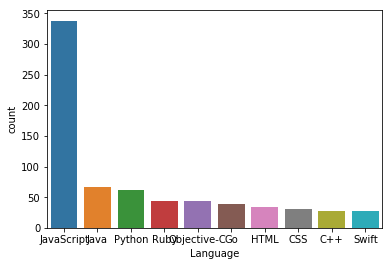

```python
sns.countplot(x="Language", data=clean_df, order=pd.value_counts(clean_df['Language']).iloc[:10].index)
```

```python
def value_to_float(x):
    if type(x) == float or type(x) == int:
        return x
    if 'K' in x:
        if len(x) > 1:
            return float(x.replace('K', '')) * 1000
        return 1000.0
    return 0.0
```

```python
clean_df.head()
```

|  | Username | Repository Name | Description | Last Update Date | Language | Number of Stars | Tags | Url |
| --- | --- | --- | --- | --- | --- | --- | --- | --- |
| 0 | freeCodeCamp | freeCodeCamp | The https://freeCodeCamp.com open source codeb... | 2017-06-24T15:56:17Z | JavaScript | 290000 | nonprofits,certification,curriculum,react,node... | https://github.com/freeCodeCamp/freeCodeCamp |
| 1 | twbs | bootstrap | The most popular HTML, CSS, and JavaScript fra... | 2017-06-24T15:40:21Z | JavaScript | 112000 | javascript,css,html,bootstrap,jekyll-site,scss | https://github.com/twbs/bootstrap |
| 3 | facebook | react | A declarative, efficient, and flexible JavaScr... | 2017-06-24T19:33:49Z | JavaScript | 69700 | NaN | https://github.com/facebook/react |
| 4 | d3 | d3 | Bring data to life with SVG, Canvas and HTML. | 2017-05-31T06:03:47Z | JavaScript | 65700 | visualization | https://github.com/d3/d3 |
| 5 | getify | You-Dont-Know-JS | A book series on JavaScript. @YDKJS on twitter. | 2017-06-23T10:42:36Z | JavaScript | 62000 | book-series,javascript,training-materials,asyn... | https://github.com/getify/You-Dont-Know-JS |

# Word Cloud visualization

## Generate overall of description keyword

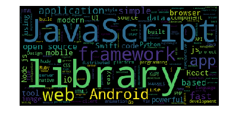

```python
wordcloud2 = WordCloud().generate(''.join(clean_df["Description"]))
# Generate plot
plt.imshow(wordcloud2)
plt.axis("off")
plt.show()
```

## Group the Language data from the completed cleaning data

```python
js = clean_df.groupby('Language').get_group("JavaScript")
jv = clean_df.groupby('Language').get_group("Java")
py = clean_df.groupby('Language').get_group("Python")
rb = clean_df.groupby('Language').get_group("Ruby")
oc = clean_df.groupby('Language').get_group("Objective-C")
go = clean_df.groupby('Language').get_group("Go")
ht = clean_df.groupby('Language').get_group("HTML")
cs = clean_df.groupby('Language').get_group("CSS")
sw = clean_df.groupby('Language').get_group("Swift")
cp = clean_df.groupby('Language').get_group("C++")
```

```python
js.head()
```

|  | Username | Repository Name | Description | Last Update Date | Language | Number of Stars | Tags | Url |
| --- | --- | --- | --- | --- | --- | --- | --- | --- |
| 0 | freeCodeCamp | freeCodeCamp | The https://freeCodeCamp.com open source codeb... | 2017-06-24T15:56:17Z | JavaScript | 290000 | nonprofits,certification,curriculum,react,node... | https://github.com/freeCodeCamp/freeCodeCamp |
| 1 | twbs | bootstrap | The most popular HTML, CSS, and JavaScript fra... | 2017-06-24T15:40:21Z | JavaScript | 112000 | javascript,css,html,bootstrap,jekyll-site,scss | https://github.com/twbs/bootstrap |
| 3 | facebook | react | A declarative, efficient, and flexible JavaScr... | 2017-06-24T19:33:49Z | JavaScript | 69700 | NaN | https://github.com/facebook/react |
| 4 | d3 | d3 | Bring data to life with SVG, Canvas and HTML. | 2017-05-31T06:03:47Z | JavaScript | 65700 | visualization | https://github.com/d3/d3 |
| 5 | getify | You-Dont-Know-JS | A book series on JavaScript. @YDKJS on twitter. | 2017-06-23T10:42:36Z | JavaScript | 62000 | book-series,javascript,training-materials,asyn... | https://github.com/getify/You-Dont-Know-JS |

### Create pop function for each language

```python
def popForLang(lang):
    return clean_df[clean_df['Language'] == lang]
```

## JavaScript

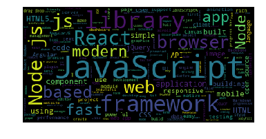

```python
wordcloud2 = WordCloud().generate(''.join(js["Description"]))
# Generate plot
plt.imshow(wordcloud2)
plt.axis("off")
plt.show()
```

```python
popForLang('JavaScript')
```

|  | Username | Repository Name | Description | Last Update Date | Language | Number of Stars | Tags | Url |
| --- | --- | --- | --- | --- | --- | --- | --- | --- |
| 0 | freeCodeCamp | freeCodeCamp | The https://freeCodeCamp.com open source codeb... | 2017-06-24T15:56:17Z | JavaScript | 290000 | nonprofits,certification,curriculum,react,node... | https://github.com/freeCodeCamp/freeCodeCamp |
| 1 | twbs | bootstrap | The most popular HTML, CSS, and JavaScript fra... | 2017-06-24T15:40:21Z | JavaScript | 112000 | javascript,css,html,bootstrap,jekyll-site,scss | https://github.com/twbs/bootstrap |
| 3 | facebook | react | A declarative, efficient, and flexible JavaScr... | 2017-06-24T19:33:49Z | JavaScript | 69700 | NaN | https://github.com/facebook/react |
| 4 | d3 | d3 | Bring data to life with SVG, Canvas and HTML. | 2017-05-31T06:03:47Z | JavaScript | 65700 | visualization | https://github.com/d3/d3 |
| 5 | getify | You-Dont-Know-JS | A book series on JavaScript. @YDKJS on twitter. | 2017-06-23T10:42:36Z | JavaScript | 62000 | book-series,javascript,training-materials,asyn... | https://github.com/getify/You-Dont-Know-JS |
| 8 | vuejs | vue | A progressive, incrementally-adoptable JavaScr... | 2017-06-24T15:38:55Z | JavaScript | 57700 | javascript,vue,framework,frontend | https://github.com/vuejs/vue |
| 9 | angular | angular.js | AngularJS - HTML enhanced for web apps! | 2017-06-24T06:25:23Z | JavaScript | 56200 | NaN | https://github.com/angular/angular.js |
| 11 | airbnb | javascript | JavaScript Style Guide | 2017-06-24T05:44:24Z | JavaScript | 54100 | arrow-functions,javascript,eslint,naming-conve... | https://github.com/airbnb/javascript |
| 14 | facebook | react-native | A framework for building native apps with React. | 2017-06-24T16:19:44Z | JavaScript | 50000 | NaN | https://github.com/facebook/react-native |
| 17 | jquery | jquery | jQuery JavaScript Library | 2017-06-23T12:47:39Z | JavaScript | 45300 | NaN | https://github.com/jquery/jquery |
| 23 | meteor | meteor | Meteor, the JavaScript App Platform | 2017-06-24T16:45:21Z | JavaScript | 37700 | javascript,meteor,npm,mongodb,build-system | https://github.com/meteor/meteor |
| 24 | h5bp | html5-boilerplate | A professional front-end template for building... | 2017-06-11T16:03:52Z | JavaScript | 37600 | NaN | https://github.com/h5bp/html5-boilerplate |
| 25 | nodejs | node | Node.js JavaScript runtime | 2017-06-24T19:42:53Z | JavaScript | 36400 | javascript,nodejs,windows,macos,linux,node,mit... | https://github.com/nodejs/node |
| 28 | Semantic-Org | Semantic-UI | Semantic is a UI component framework based aro... | 2017-06-19T17:49:04Z | JavaScript | 35600 | semantic,flexbox,ui,css-framework,tooltip,butt... | https://github.com/Semantic-Org/Semantic-UI |
| 30 | hakimel | reveal.js | The HTML Presentation Framework | 2017-06-19T09:07:01Z | JavaScript | 35200 | slideshow,slides,presentations | https://github.com/hakimel/reveal.js |
| 31 | socketio | socket.io | Realtime application framework (Node.JS server) | 2017-06-23T01:04:59Z | JavaScript | 33800 | NaN | https://github.com/socketio/socket.io |
| 32 | mrdoob | three.js | JavaScript 3D library. | 2017-06-24T18:40:38Z | JavaScript | 33600 | javascript,svg,webgl,html5,canvas,scene-graph | https://github.com/mrdoob/three.js |
| 34 | expressjs | express | Fast, unopinionated, minimalist web framework ... | 2017-06-22T15:34:50Z | JavaScript | 32500 | javascript,nodejs,express,server | https://github.com/expressjs/express |
| 35 | reactjs | redux | Predictable state container for JavaScript apps | 2017-06-23T21:05:09Z | JavaScript | 32000 | redux | https://github.com/reactjs/redux |
| 36 | moment | moment | Parse, validate, manipulate, and display dates... | 2017-06-24T15:53:46Z | JavaScript | 31900 | NaN | https://github.com/moment/moment |
| 37 | impress | impress.js | It's a presentation framework based on the pow... | 2017-05-15T15:25:45Z | JavaScript | 31800 | NaN | https://github.com/impress/impress.js |
| 40 | chartjs | Chart.js | Simple HTML5 Charts using the <canvas> tag | 2017-06-24T19:40:15Z | JavaScript | 30700 | html5-charts,chart,javascript,html5,canvas,graph | https://github.com/chartjs/Chart.js |
| 46 | webpack | webpack | A bundler for javascript and friends. Packs ma... | 2017-06-24T01:42:43Z | JavaScript | 29400 | javascript,webpack,commonjs,amd,module-loader,... | https://github.com/webpack/webpack |
| 47 | resume | resume.github.com | Resumes generated using the GitHub informations | 2017-01-30T13:08:05Z | JavaScript | 29400 | NaN | https://github.com/resume/resume.github.com |
| 50 | facebookincubator | create-react-app | Create React apps with no build configuration. | 2017-06-23T19:23:25Z | JavaScript | 29100 | react,zero-configuration,build-tools | https://github.com/facebookincubator/create-re... |
| 55 | NARKOZ | hacker-scripts | Based on a true story | 2017-05-14T18:32:58Z | JavaScript | 27800 | NaN | https://github.com/NARKOZ/hacker-scripts |
| 57 | adobe | brackets | An open source code editor for the web, writte... | 2017-06-23T20:18:00Z | JavaScript | 27600 | NaN | https://github.com/adobe/brackets |
| 58 | Dogfalo | materialize | Materialize, a CSS Framework based on Material... | 2017-06-24T17:56:32Z | JavaScript | 27200 | material,css,design | https://github.com/Dogfalo/materialize |
| 59 | blueimp | jQuery-File-Upload | File Upload widget with multiple file selectio... | 2017-05-18T20:04:36Z | JavaScript | 26900 | NaN | https://github.com/blueimp/jQuery-File-Upload |
| 62 | gulpjs | gulp | The streaming build system | 2017-06-24T02:51:24Z | JavaScript | 26600 | NaN | https://github.com/gulpjs/gulp |
| ... | ... | ... | ... | ... | ... | ... | ... | ... |
| 887 | mishoo | UglifyJS2 | JavaScript parser / mangler / compressor / bea... | 2017-06-24T13:30:07Z | JavaScript | 6800 | NaN | https://github.com/mishoo/UglifyJS2 |
| 891 | seajs | seajs | A Module Loader for the Web | 2017-05-22T02:53:11Z | JavaScript | 6800 | NaN | https://github.com/seajs/seajs |
| 895 | giakki | uncss | Remove unused styles from CSS | 2017-06-21T07:59:39Z | JavaScript | 6800 | NaN | https://github.com/giakki/uncss |
| 899 | feathersjs | feathers | A REST and realtime API layer for modern appli... | 2017-06-23T12:05:41Z | JavaScript | 6800 | feathersjs,javascript,nodejs,browser,react-native | https://github.com/feathersjs/feathers |
| 902 | facebook | nuclide | An open IDE for web and native mobile developm... | 2017-06-24T00:45:51Z | JavaScript | 6800 | NaN | https://github.com/facebook/nuclide |
| 908 | hpneo | gmaps | the easiest way to use Google Maps | 2017-05-22T13:53:12Z | JavaScript | 6700 | NaN | https://github.com/hpneo/gmaps |
| 910 | angular | protractor | E2E test framework for Angular apps | 2017-06-22T08:05:57Z | JavaScript | 6700 | protractor,angular,javascript,node,webdriver,t... | https://github.com/angular/protractor |
| 911 | casperjs | casperjs | Navigation scripting and testing utility for P... | 2017-06-13T03:44:50Z | JavaScript | 6700 | phantomjs,javascript,headless-testing,headless... | https://github.com/casperjs/casperjs |
| 913 | shekhargulati | 52-technologies-in-2016 | Let's learn a new technology every week. A new... | 2017-04-20T08:46:36Z | JavaScript | 6700 | tutorial,blog,learning | https://github.com/shekhargulati/52-technologi... |
| 914 | erikras | redux-form | A Higher Order Component using react-redux to ... | 2017-06-24T15:20:57Z | JavaScript | 6700 | react,redux-form,redux,validation,forms,form,f... | https://github.com/erikras/redux-form |
| 919 | mozilla | metrics-graphics | A library optimized for concise and principled... | 2017-04-28T13:37:42Z | JavaScript | 6700 | NaN | https://github.com/mozilla/metrics-graphics |
| 921 | louischatriot | nedb | The JavaScript Database, for Node.js, nw.js, e... | 2017-06-06T16:57:33Z | JavaScript | 6700 | NaN | https://github.com/louischatriot/nedb |
| 922 | Famous | famous | This repo is being deprecated. Please check ou... | 2017-04-18T05:09:14Z | JavaScript | 6700 | NaN | https://github.com/Famous/famous |
| 926 | Mango | slideout | A touch slideout navigation menu for your mobi... | 2017-06-13T16:08:26Z | JavaScript | 6600 | touch-events,slideout-menu,sidebar,menu-naviga... | https://github.com/Mango/slideout |
| 929 | OAI | OpenAPI-Specification | The OpenAPI Specification Repository | 2017-06-23T11:30:27Z | JavaScript | 6600 | NaN | https://github.com/OAI/OpenAPI-Specification |
| 932 | flightjs | flight | A component-based, event-driven JavaScript fra... | 2017-06-19T21:40:19Z | JavaScript | 6600 | NaN | https://github.com/flightjs/flight |
| 933 | nightwatchjs | nightwatch | Automated testing and continous integration fr... | 2017-06-23T21:23:22Z | JavaScript | 6600 | javascript,selenium-webdriver,coverage,nightwa... | https://github.com/nightwatchjs/nightwatch |
| 935 | nlp-compromise | compromise | Natural language processing in javascript | 2017-06-23T22:26:30Z | JavaScript | 6600 | nlp,named-entity-recognition,part-of-speech | https://github.com/nlp-compromise/compromise |
| 936 | xing | wysihtml5 | Open source rich text editor based on HTML5 an... | 2016-04-02T13:08:16Z | JavaScript | 6600 | NaN | https://github.com/xing/wysihtml5 |
| 937 | twitter | twemoji | Twitter Emoji for Everyone | 2017-05-23T21:17:56Z | JavaScript | 6600 | NaN | https://github.com/twitter/twemoji |
| 941 | howdyai | botkit | Botkit is a toolkit for making bot applications | 2017-06-23T03:00:31Z | JavaScript | 6600 | botkit-studio,slack,botkit-bots,microsoft-bot-... | https://github.com/howdyai/botkit |
| 946 | NaturalNode | natural | general natural language facilities for node | 2017-06-22T13:36:13Z | JavaScript | 6500 | NaN | https://github.com/NaturalNode/natural |
| 950 | aFarkas | lazysizes | High performance and SEO friendly lazy loader ... | 2017-06-15T21:16:43Z | JavaScript | 6500 | javascript,lazysizes,performance,lazyload,lazy... | https://github.com/aFarkas/lazysizes |
| 952 | maxogden | art-of-node | a short introduction to node.js | 2017-06-16T13:14:26Z | JavaScript | 6500 | NaN | https://github.com/maxogden/art-of-node |
| 958 | desandro | imagesloaded | JavaScript is all like "You images done yet o... | 2017-06-12T19:19:55Z | JavaScript | 6500 | NaN | https://github.com/desandro/imagesloaded |
| 959 | react-toolbox | react-toolbox | A set of React components implementing Google'... | 2017-06-23T12:09:15Z | JavaScript | 6500 | NaN | https://github.com/react-toolbox/react-toolbox |
| 962 | rethinkdb | horizon | Horizon is a realtime, open-source backend for... | 2017-05-31T12:07:10Z | JavaScript | 6500 | NaN | https://github.com/rethinkdb/horizon |
| 969 | bodymovin | bodymovin | after effects to html library | 2017-06-21T11:24:06Z | JavaScript | 6400 | NaN | https://github.com/bodymovin/bodymovin |
| 973 | plotly | plotly.js | The open source JavaScript graphing library th... | 2017-06-23T21:32:19Z | JavaScript | 6400 | d3,webgl,charting-library,plotly,data-visualiz... | https://github.com/plotly/plotly.js |
| 974 | poteto | hiring-without-whiteboards | Companies that don't have a broken hiring pro... | 2017-06-23T22:40:38Z | JavaScript | 6400 | whiteboard,interview,tech,jobs,hiring,airtable... | https://github.com/poteto/hiring-without-white... |

338 rows × 8 columns

## Java

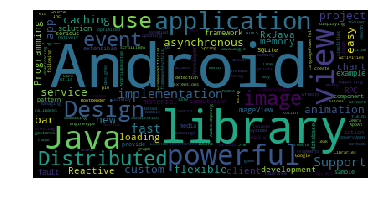

```python
wordcloud2 = WordCloud().generate(''.join(jv["Description"]))
# Generate plot
plt.imshow(wordcloud2)
plt.axis("off")
plt.show()
```

```python
popForLang('Java')
```

|  | Username | Repository Name | Description | Last Update Date | Language | Number of Stars | Tags | Url |
| --- | --- | --- | --- | --- | --- | --- | --- | --- |
| 70 | ReactiveX | RxJava | RxJava Reactive Extensions for the JVM a lib... | 2017-06-24T11:34:48Z | Java | 25200 | flow,reactive-streams,java,rxjava | https://github.com/ReactiveX/RxJava |
| 82 | elastic | elasticsearch | Open Source, Distributed, RESTful Search Engine | 2017-06-24T18:33:40Z | Java | 23400 | java,search-engine,elasticsearch | https://github.com/elastic/elasticsearch |
| 95 | square | retrofit | Type-safe HTTP client for Android and Java by ... | 2017-06-23T18:50:14Z | Java | 22000 | NaN | https://github.com/square/retrofit |
| 110 | square | okhttp | An HTTP+HTTP/2 client for Android and Java app... | 2017-06-24T08:33:24Z | Java | 20600 | NaN | https://github.com/square/okhttp |
| 117 | iluwatar | java-design-patterns | Design patterns implemented in Java | 2017-06-15T22:05:13Z | Java | 19800 | principles,java,design-patterns | https://github.com/iluwatar/java-design-patterns |
| 163 | google | guava | Google Core Libraries for Java | 2017-06-23T19:50:20Z | Java | 17100 | NaN | https://github.com/google/guava |
| 172 | JakeWharton | butterknife | Bind Android views and callbacks to fields and... | 2017-06-24T14:25:19Z | Java | 16700 | NaN | https://github.com/JakeWharton/butterknife |
| 184 | PhilJay | MPAndroidChart | A powerful Android chart view / graph view lib... | 2017-06-23T00:02:59Z | Java | 16400 | NaN | https://github.com/PhilJay/MPAndroidChart |
| 188 | bumptech | glide | An image loading and caching library for Andro... | 2017-06-24T13:00:33Z | Java | 16100 | NaN | https://github.com/bumptech/glide |
| 198 | square | leakcanary | A memory leak detection library for Android an... | 2017-06-23T21:39:41Z | Java | 15700 | NaN | https://github.com/square/leakcanary |
| 202 | JetBrains | kotlin | The Kotlin Programming Language | 2017-06-24T14:26:26Z | Java | 15500 | kotlin,kotlin-library,programming-language,com... | https://github.com/JetBrains/kotlin |
| 206 | nostra13 | Android-Universal-Image-Loader | Powerful and flexible library for loading, cac... | 2017-02-03T13:07:52Z | Java | 15400 | NaN | https://github.com/nostra13/Android-Universal-... |
| 217 | greenrobot | EventBus | Android optimized event bus that simplifies co... | 2017-06-19T05:45:39Z | Java | 14900 | NaN | https://github.com/greenrobot/EventBus |
| 233 | spring-projects | spring-framework | The Spring Framework | 2017-06-23T23:19:21Z | Java | 14600 | NaN | https://github.com/spring-projects/spring-fram... |
| 250 | zxing | zxing | Official ZXing ("Zebra Crossing") project home | 2017-06-16T12:51:14Z | Java | 14100 | java,zxing,android,barcode,barcode-scanner | https://github.com/zxing/zxing |
| 266 | square | picasso | A powerful image downloading and caching libra... | 2017-06-01T23:23:02Z | Java | 13600 | NaN | https://github.com/square/picasso |
| 269 | spring-projects | spring-boot | Spring Boot | 2017-06-24T17:50:46Z | Java | 13600 | NaN | https://github.com/spring-projects/spring-boot |
| 270 | airbnb | lottie-android | Render After Effects animations natively on An... | 2017-06-22T22:50:30Z | Java | 13500 | lottie,animation,android,airbnb,after-effects | https://github.com/airbnb/lottie-android |
| 271 | google | iosched | The Google I/O 2016 Android App | 2017-05-01T18:10:20Z | Java | 13500 | NaN | https://github.com/google/iosched |
| 294 | facebook | fresco | An Android library for managing images and the... | 2017-06-22T12:38:18Z | Java | 12900 | NaN | https://github.com/facebook/fresco |
| 297 | ReactiveX | RxAndroid | RxJava bindings for Android | 2017-05-06T19:59:03Z | Java | 12800 | NaN | https://github.com/ReactiveX/RxAndroid |
| 335 | libgdx | libgdx | Desktop/Android/HTML5/iOS Java game developmen... | 2017-06-23T15:40:39Z | Java | 11800 | game,java,libgdx,android,windows,linux,ios,fra... | https://github.com/libgdx/libgdx |
| 370 | Blankj | AndroidUtilCode | Android developers should collect the followi... | 2017-06-24T15:09:06Z | Java | 11000 | snackbar,toast,android,app,time,log,network,ph... | https://github.com/Blankj/AndroidUtilCode |
| 401 | jfeinstein10 | SlidingMenu | An Android library that allows you to easily c... | 2017-03-31T02:15:51Z | Java | 10500 | NaN | https://github.com/jfeinstein10/SlidingMenu |
| 412 | chrisbanes | PhotoView | Implementation of ImageView for Android that s... | 2017-06-15T15:37:43Z | Java | 10400 | NaN | https://github.com/chrisbanes/PhotoView |
| 415 | netty | netty | Netty project - an event-driven asynchronous n... | 2017-06-24T03:10:39Z | Java | 10400 | NaN | https://github.com/netty/netty |
| 422 | Netflix | Hystrix | Hystrix is a latency and fault tolerance libra... | 2017-06-22T02:59:31Z | Java | 10000 | NaN | https://github.com/Netflix/Hystrix |
| 442 | loopj | android-async-http | An Asynchronous HTTP Library for Android | 2017-02-24T13:49:50Z | Java | 9900 | NaN | https://github.com/loopj/android-async-http |
| 455 | kdn251 | interviews | Everything you need to know to get the job. | 2017-05-31T21:01:03Z | Java | 9800 | java,algorithm,algorithms,leetcode,interview,i... | https://github.com/kdn251/interviews |
| 494 | alibaba | fastjson | A fast JSON parser/generator for Java | 2017-06-24T15:07:08Z | Java | 9500 | fastjson,java,android,serialization,json,json-... | https://github.com/alibaba/fastjson |
| ... | ... | ... | ... | ... | ... | ... | ... | ... |
| 567 | android10 | Android-CleanArchitecture | This is a sample app that is part of a series ... | 2017-03-07T13:28:18Z | Java | 8900 | java,architectural,android-cleanarchitecture,a... | https://github.com/android10/Android-CleanArch... |
| 575 | pockethub | PocketHub | PocketHub Android App | 2017-06-24T11:42:31Z | Java | 8800 | NaN | https://github.com/pockethub/PocketHub |
| 624 | google | flexbox-layout | Flexbox for Android | 2017-06-23T08:05:36Z | Java | 8400 | android,flexbox,android-library | https://github.com/google/flexbox-layout |
| 642 | navasmdc | MaterialDesignLibrary | This is a library with components of Android L... | 2017-02-14T06:42:19Z | Java | 8200 | NaN | https://github.com/navasmdc/MaterialDesignLibrary |
| 644 | chrisbanes | Android-PullToRefresh | DEPRECATED | 2016-09-22T00:15:44Z | Java | 8200 | NaN | https://github.com/chrisbanes/Android-PullToRe... |
| 653 | daimajia | AndroidSwipeLayout | The Most Powerful Swipe Layout! | 2017-04-07T11:02:48Z | Java | 8200 | NaN | https://github.com/daimajia/AndroidSwipeLayout |
| 676 | liaohuqiu | android-Ultra-Pull-To-Refresh | Ultra Pull to Refresh for Android. Support all... | 2017-02-06T07:52:06Z | Java | 8000 | NaN | https://github.com/liaohuqiu/android-Ultra-Pul... |
| 682 | realm | realm-java | Realm is a mobile database: a replacement for ... | 2017-06-24T07:27:13Z | Java | 8000 | java,android,mobile,database,realtime-database... | https://github.com/realm/realm-java |
| 683 | WhisperSystems | Signal-Android | A private messenger for Android. | 2017-06-24T16:33:15Z | Java | 8000 | NaN | https://github.com/WhisperSystems/Signal-Android |
| 687 | greenrobot | greenDAO | greenDAO is a light & fast ORM solution for An... | 2017-06-12T06:47:51Z | Java | 7900 | NaN | https://github.com/greenrobot/greenDAO |
| 691 | CymChad | BaseRecyclerViewAdapterHelper | Powerful and flexible RecyclerAdapter, www.rec... | 2017-06-23T08:18:34Z | Java | 7900 | android,recyclerview,android-library,recyclerv... | https://github.com/CymChad/BaseRecyclerViewAda... |
| 692 | googlesamples | android-UniversalMusicPlayer | This sample shows how to implement an audio me... | 2017-06-13T22:35:41Z | Java | 7900 | NaN | https://github.com/googlesamples/android-Unive... |
| 700 | facebook | stetho | Stetho is a debug bridge for Android applicati... | 2017-05-14T05:54:40Z | Java | 7900 | NaN | https://github.com/facebook/stetho |
| 746 | daimajia | AndroidViewAnimations | Cute view animation collection. | 2017-05-06T14:39:26Z | Java | 7700 | android,easing-functions,animation | https://github.com/daimajia/AndroidViewAnimations |
| 748 | mikepenz | MaterialDrawer | The flexible, easy to use, all in one drawer l... | 2017-06-18T17:08:10Z | Java | 7700 | android,java,drawer,materialdrawer,navigation-... | https://github.com/mikepenz/MaterialDrawer |
| 751 | ksoichiro | Android-ObservableScrollView | Android library to observe scroll events on sc... | 2016-07-27T06:48:05Z | Java | 7600 | android-library,android,material-design,androi... | https://github.com/ksoichiro/Android-Observabl... |
| 754 | HannahMitt | HomeMirror | Android application powering the mirror in my ... | 2017-06-14T03:23:50Z | Java | 7600 | NaN | https://github.com/HannahMitt/HomeMirror |
| 791 | JakeWharton | ActionBarSherlock | [DEPRECATED] Action bar implementation which u... | 2015-12-17T17:54:50Z | Java | 7400 | NaN | https://github.com/JakeWharton/ActionBarSherlock |
| 798 | EnterpriseQualityCoding | FizzBuzzEnterpriseEdition | FizzBuzz Enterprise Edition is a no-nonsense i... | 2017-03-02T21:29:06Z | Java | 7300 | NaN | https://github.com/EnterpriseQualityCoding/Fiz... |
| 806 | hdodenhof | CircleImageView | A circular ImageView for Android | 2017-05-13T23:57:59Z | Java | 7300 | android,imageview,widget | https://github.com/hdodenhof/CircleImageView |
| 814 | winterbe | java8-tutorial | Modern Java - A Guide to Java 8 | 2017-06-12T06:25:47Z | Java | 7300 | lambda-expressions,java,stream,parallel-stream... | https://github.com/winterbe/java8-tutorial |
| 848 | google | ExoPlayer | An extensible media player for Android | 2017-06-24T13:42:52Z | Java | 7000 | exoplayer,java,android,mediaplayer | https://github.com/google/ExoPlayer |
| 877 | deeplearning4j | deeplearning4j | Deep Learning for Java, Scala & Clojure on Had... | 2017-06-24T09:16:05Z | Java | 6900 | intellij,hadoop,neural-nets,gpu,deeplearning4j... | https://github.com/deeplearning4j/deeplearning4j |
| 896 | chrisbanes | cheesesquare | Demos the new Android Design library. | 2017-06-09T09:37:10Z | Java | 6800 | NaN | https://github.com/chrisbanes/cheesesquare |
| 905 | orhanobut | logger | Simple, pretty and powerful logger for android | 2017-06-06T11:56:31Z | Java | 6700 | android,java,log,logger,logcat,timber,pretty-p... | https://github.com/orhanobut/logger |
| 923 | alibaba | druid |  | 2017-06-24T15:07:38Z | Java | 6700 | NaN | https://github.com/alibaba/druid |
| 938 | google | agera | Reactive Programming for Android | 2017-04-24T15:05:17Z | Java | 6600 | android,agera,reactive | https://github.com/google/agera |
| 939 | bazelbuild | bazel | a fast, scalable, multi-language and extensibl... | 2017-06-23T17:42:55Z | Java | 6600 | bazel,build,test,fast,correct,scalable,multi-l... | https://github.com/bazelbuild/bazel |
| 965 | roughike | BottomBar | A custom view component that mimics the new Ma... | 2017-06-21T15:43:32Z | Java | 6500 | android,java,library,material-design,bottom-na... | https://github.com/roughike/BottomBar |
| 975 | chrisjenx | Calligraphy | Custom fonts in Android the easy way... | 2017-06-06T19:23:22Z | Java | 6400 | NaN | https://github.com/chrisjenx/Calligraphy |

67 rows × 8 columns

## Python

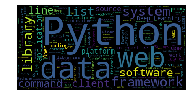

```python
wordcloud2 = WordCloud().generate(''.join(py["Description"]))
# Generate plot
plt.imshow(wordcloud2)
plt.axis("off")
plt.show()
```

```python
popForLang('Python')
```

|  | Username | Repository Name | Description | Last Update Date | Language | Number of Stars | Tags | Url |
| --- | --- | --- | --- | --- | --- | --- | --- | --- |
| 29 | vinta | awesome-python | A curated list of awesome Python frameworks, l... | 2017-06-18T09:43:08Z | Python | 35300 | python,awesome,collections | https://github.com/vinta/awesome-python |
| 42 | jakubroztocil | httpie | Modern command line HTTP client user-friendly... | 2017-06-18T06:18:33Z | Python | 30200 | python,debugging,cli,http,client,json,developm... | https://github.com/jakubroztocil/httpie |
| 52 | nvbn | thefuck | Magnificent app which corrects your previous c... | 2017-06-19T21:12:47Z | Python | 28600 | python,shell | https://github.com/nvbn/thefuck |
| 54 | pallets | flask | A microframework based on Werkzeug, Jinja2 and... | 2017-06-21T23:13:36Z | Python | 27800 | python,flask,web-framework,wsgi,jinja,werkzeug | https://github.com/pallets/flask |
| 60 | rg3 | youtube-dl | Command-line program to download videos from Y... | 2017-06-24T19:15:47Z | Python | 26900 | NaN | https://github.com/rg3/youtube-dl |
| 65 | django | django | The Web framework for perfectionists with dead... | 2017-06-24T14:49:32Z | Python | 26400 | python,django,views,framework,orm,web,apps,tem... | https://github.com/django/django |
| 67 | requests | requests | Python HTTP Requests for Humans | 2017-06-16T22:31:24Z | Python | 25700 | python,http,requests,forhumans,kennethreitz | https://github.com/requests/requests |
| 77 | ansible | ansible | Ansible is a radically simple IT automation pl... | 2017-06-24T19:07:24Z | Python | 23900 | python,ansible | https://github.com/ansible/ansible |
| 79 | josephmisiti | awesome-machine-learning | A curated list of awesome Machine Learning fra... | 2017-06-24T16:58:31Z | Python | 23700 | NaN | https://github.com/josephmisiti/awesome-machin... |
| 104 | minimaxir | big-list-of-naughty-strings | The Big List of Naughty Strings is a list of s... | 2017-05-26T17:09:45Z | Python | 21200 | NaN | https://github.com/minimaxir/big-list-of-naugh... |
| 105 | scrapy | scrapy | Scrapy, a fast high-level web crawling & scrap... | 2017-06-23T16:10:23Z | Python | 21200 | python,crawler,framework,scraping,crawling | https://github.com/scrapy/scrapy |
| 124 | scikit-learn | scikit-learn | scikit-learn: machine learning in Python | 2017-06-24T18:53:10Z | Python | 19400 | python,data-science,machine-learning,statistic... | https://github.com/scikit-learn/scikit-learn |
| 131 | certbot | certbot | Certbot, previously the Let's Encrypt Client, ... | 2017-06-23T16:41:03Z | Python | 18900 | python,letsencrypt,acme-client,certificate,acm... | https://github.com/certbot/certbot |
| 141 | shadowsocks | shadowsocks | Updated Jun 24, 2017 | 2017-06-24T04:23:52Z | Python | 18200 | NaN | https://github.com/shadowsocks/shadowsocks |
| 151 | tensorflow | models | Models built with TensorFlow | 2017-06-23T23:19:11Z | Python | 17600 | NaN | https://github.com/tensorflow/models |
| 153 | donnemartin | system-design-primer | Learn how to design large-scale systems. Prep ... | 2017-06-21T01:11:07Z | Python | 17500 | interview-questions,python,design,development,... | https://github.com/donnemartin/system-design-p... |
| 170 | fchollet | keras | Deep Learning library for Python. Runs on Tens... | 2017-06-24T17:51:46Z | Python | 16900 | theano,tensorflow,deep-learning,data-science,m... | https://github.com/fchollet/keras |
| 218 | XX-net | XX-Net | a web proxy tool | 2017-06-17T12:23:47Z | Python | 14900 | xx-net,goagent,gfw | https://github.com/XX-net/XX-Net |
| 230 | ApacheInfra | superset | Apache Superset (incubating) is a modern, ente... | 2017-06-24T12:00:50Z | Python | 14700 | druid,data,data-visualization,dashboards,data-... | https://github.com/ApacheInfra/superset |
| 249 | Valloric | YouCompleteMe | A code-completion engine for Vim | 2017-06-21T00:58:30Z | Python | 14100 | semantic-engine,vim,code-analysis,code-completion | https://github.com/Valloric/YouCompleteMe |
| 251 | isocpp | CppCoreGuidelines | The C++ Core Guidelines are a set of tried-and... | 2017-06-21T01:05:20Z | Python | 14000 | NaN | https://github.com/isocpp/CppCoreGuidelines |
| 265 | tornadoweb | tornado | Tornado is a Python web framework and asynchro... | 2017-06-21T04:05:46Z | Python | 13700 | python,asynchronous | https://github.com/tornadoweb/tornado |
| 273 | soimort | you-get | Dumb downloader that scrapes the web | 2017-06-21T15:58:20Z | Python | 13400 | NaN | https://github.com/soimort/you-get |
| 278 | reddit | reddit | the code that powers reddit.com | 2017-06-13T22:40:11Z | Python | 13400 | python,javascript,reddit | https://github.com/reddit/reddit |
| 291 | getsentry | sentry | Sentry is a cross-platform crash reporting and... | 2017-06-24T18:38:04Z | Python | 13000 | python,devops,django,monitoring,crash-reportin... | https://github.com/getsentry/sentry |
| 322 | songrotek | Deep-Learning-Papers-Reading-Roadmap | Deep Learning papers reading roadmap for anyon... | 2017-06-08T02:05:19Z | Python | 12200 | deep-learning | https://github.com/songrotek/Deep-Learning-Pap... |
| 339 | faif | python-patterns | A collection of design patterns/idioms in Python | 2017-06-20T19:02:44Z | Python | 11700 | python,idioms,design-patterns | https://github.com/faif/python-patterns |
| 344 | ipython | ipython | Official repository for IPython itself. Other ... | 2017-06-22T08:00:59Z | Python | 11600 | python,data-science,jupyter,notebook,ipython,repl | https://github.com/ipython/ipython |
| 354 | drduh | macOS-Security-and-Privacy-Guide | A practical guide to securing macOS. | 2017-05-23T23:00:23Z | Python | 11500 | disk-encryption,privacy,apple,macos,security,o... | https://github.com/drduh/macOS-Security-and-Pr... |
| 372 | adobe-fonts | source-code-pro | Monospaced font family for user interface and ... | 2017-03-23T06:29:09Z | Python | 11000 | opentype-fonts,otf,font | https://github.com/adobe-fonts/source-code-pro |
| ... | ... | ... | ... | ... | ... | ... | ... | ... |
| 440 | docker | compose | Define and run multi-container applications wi... | 2017-06-24T00:43:15Z | Python | 9900 | docker,python,docker-compose,orchestration | https://github.com/docker/compose |
| 503 | donnemartin | data-science-ipython-notebooks | Recently updated with 50 new notebooks! Data s... | 2017-06-19T00:10:25Z | Python | 9400 | python,deep-learning,kaggle,numpy,scikit-learn... | https://github.com/donnemartin/data-science-ip... |
| 510 | equinusocio | material-theme | Material Theme, the most epic theme for Sublim... | 2017-06-23T10:15:13Z | Python | 9400 | material-theme,sublime-text,material-ui,theme,... | https://github.com/equinusocio/material-theme |
| 527 | chrissimpkins | Hack | A typeface designed for source code | 2017-06-19T14:42:13Z | Python | 9200 | typeface,font,developer,developer-tools,ttf,fo... | https://github.com/chrissimpkins/Hack |
| 552 | binux | pyspider | A Powerful Spider(Web Crawler) System in Python. | 2017-06-20T22:10:52Z | Python | 9000 | python,crawler | https://github.com/binux/pyspider |
| 571 | sqlmapproject | sqlmap | Automatic SQL injection and database takeover ... | 2017-06-23T21:46:35Z | Python | 8900 | python,database,detection,sql-injection,pentes... | https://github.com/sqlmapproject/sqlmap |
| 587 | fabric | fabric | Simple, Pythonic remote execution and deployment. | 2017-06-06T00:00:11Z | Python | 8700 | NaN | https://github.com/fabric/fabric |
| 603 | keon | algorithms | Minimal examples of data structures and algori... | 2017-06-22T23:26:41Z | Python | 8500 | algorithm,python,data-structure,interview,comp... | https://github.com/keon/algorithms |
| 620 | python | cpython | The Python programming language | 2017-06-24T19:25:55Z | Python | 8400 | NaN | https://github.com/python/cpython |
| 646 | Rochester-NRT | RocAlphaGo | An independent, student-led replication of Dee... | 2017-06-21T13:59:49Z | Python | 8200 | NaN | https://github.com/Rochester-NRT/RocAlphaGo |
| 658 | apenwarr | sshuttle | Transparent proxy server that works as a poor ... | 2017-05-05T09:19:26Z | Python | 8200 | NaN | https://github.com/apenwarr/sshuttle |
| 668 | encode | django-rest-framework | Web APIs for Django. | 2017-06-24T05:33:55Z | Python | 8100 | NaN | https://github.com/encode/django-rest-framework |
| 684 | mitmproxy | mitmproxy | An interactive TLS-capable intercepting HTTP p... | 2017-06-24T17:54:05Z | Python | 8000 | python,tls,ssl,http,security,proxy,websocket,h... | https://github.com/mitmproxy/mitmproxy |
| 696 | alexjc | neural-doodle | Turn your two-bit doodles into fine artworks w... | 2016-12-28T15:58:48Z | Python | 7900 | NaN | https://github.com/alexjc/neural-doodle |
| 716 | atlassian | localstack | A fully functional local AWS cloud stack. Deve... | 2017-06-22T04:43:17Z | Python | 7800 | aws | https://github.com/atlassian/localstack |
| 721 | saltstack | salt | Software to automate the management and config... | 2017-06-24T15:00:26Z | Python | 7800 | python,event-stream,zeromq,cloud-providers,eve... | https://github.com/saltstack/salt |
| 742 | HelloZeroNet | ZeroNet | ZeroNet - Decentralized websites using Bitcoin... | 2017-06-20T22:03:36Z | Python | 7700 | bitcoin,bittorrent,torrent,web,decentralized,r... | https://github.com/HelloZeroNet/ZeroNet |
| 752 | powerline | powerline | Powerline is a statusline plugin for vim, and ... | 2017-06-08T01:06:53Z | Python | 7600 | python,vim,bash,zsh,tmux,fish,ipython,prompt,p... | https://github.com/powerline/powerline |
| 768 | nicolargo | glances | Glances an Eye on your system. A top/htop alte... | 2017-06-23T00:49:59Z | Python | 7500 | python,multi-platform,terminal,web,monitoring,... | https://github.com/nicolargo/glances |
| 824 | spotify | luigi | Luigi is a Python module that helps you build ... | 2017-06-24T09:24:47Z | Python | 7200 | python,hadoop,scheduling,orchestration-framewo... | https://github.com/spotify/luigi |
| 827 | home-assistant | home-assistant | Open-source home automation platform running ... | 2017-06-24T19:14:58Z | Python | 7200 | python,home-automation,mqtt,raspberry-pi,iot,i... | https://github.com/home-assistant/home-assistant |
| 842 | celery | celery | Distributed Task Queue (development branch) | 2017-06-22T23:28:18Z | Python | 7000 | NaN | https://github.com/celery/celery |
| 857 | getpelican | pelican | Static site generator that supports Markdown a... | 2017-06-22T19:49:27Z | Python | 7000 | python,static-site-generator,pelican | https://github.com/getpelican/pelican |
| 861 | mailpile | Mailpile | A free & open modern, fast email client with u... | 2017-06-23T23:07:42Z | Python | 7000 | NaN | https://github.com/mailpile/Mailpile |
| 876 | odoo | odoo | Odoo. Open Source Apps To Grow Your Business. | 2017-06-24T17:35:43Z | Python | 6900 | odoo,odoo-apps,python,business,erp,apps,manage... | https://github.com/odoo/odoo |
| 883 | getredash | redash | Make Your Company Data Driven. Connect to any ... | 2017-06-24T11:57:01Z | Python | 6800 | redshift,python,visualization,redash,mysql,big... | https://github.com/getredash/redash |
| 906 | alexjc | neural-enhance | Super Resolution for images using deep learning. | 2017-04-16T03:19:36Z | Python | 6700 | NaN | https://github.com/alexjc/neural-enhance |
| 955 | Theano | Theano | Theano is a Python library that allows you to ... | 2017-06-24T04:38:31Z | Python | 6500 | NaN | https://github.com/Theano/Theano |
| 967 | google | python-fire | Python Fire is a library for automatically gen... | 2017-06-19T00:14:54Z | Python | 6500 | NaN | https://github.com/google/python-fire |
| 976 | eliangcs | http-prompt | HTTPie + prompt_toolkit = an interactive comma... | 2017-05-11T13:27:42Z | Python | 6400 | python,syntax-highlighting,shell,cli,http,auto... | https://github.com/eliangcs/http-prompt |

62 rows × 8 columns

## Ruby

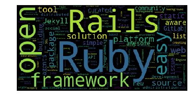

```python
wordcloud2 = WordCloud().generate(''.join(rb["Description"]))
# Generate plot
plt.imshow(wordcloud2)
plt.axis("off")
plt.show()
```

```python
popForLang('Ruby')
```

|  | Username | Repository Name | Description | Last Update Date | Language | Number of Stars | Tags | Url |
| --- | --- | --- | --- | --- | --- | --- | --- | --- |
| 27 | rails | rails | Ruby on Rails | 2017-06-24T16:02:00Z | Ruby | 36100 | rails,ruby,html,mvc,activerecord,activejob | https://github.com/rails/rails |
| 44 | jekyll | jekyll | Jekyll is a blog-aware, static site generator... | 2017-06-24T16:32:00Z | Ruby | 30100 | ruby,jekyll,static-site-generator | https://github.com/jekyll/jekyll |
| 51 | Homebrew | legacy-homebrew | The former home of Homebrew | 2017-05-27T11:25:40Z | Ruby | 29000 | NaN | https://github.com/Homebrew/legacy-homebrew |
| 96 | discourse | discourse | A platform for community discussion. Free, ope... | 2017-06-23T21:20:59Z | Ruby | 21900 | ruby,rails,discourse,emberjs | https://github.com/discourse/discourse |
| 122 | gitlabhq | gitlabhq | GitLab CE \| Please open new issues in our issu... | 2017-06-22T16:10:32Z | Ruby | 19500 | ruby,gitlab,rails | https://github.com/gitlabhq/gitlabhq |
| 130 | bayandin | awesome-awesomeness | A curated list of awesome awesomeness | 2017-06-21T13:40:41Z | Ruby | 19100 | NaN | https://github.com/bayandin/awesome-awesomeness |
| 159 | plataformatec | devise | Flexible authentication solution for Rails wit... | 2017-06-24T15:37:01Z | Ruby | 17200 | rails,devise,ruby,plataformatec,authentication | https://github.com/plataformatec/devise |
| 176 | fastlane | fastlane | The easiest way to automate building and rele... | 2017-06-24T20:06:06Z | Ruby | 16600 | fastlane,android,ios,screenshots,automation,mo... | https://github.com/fastlane/fastlane |
| 181 | huginn | huginn | Create agents that monitor and act on your beh... | 2017-06-15T07:27:52Z | Ruby | 16400 | NaN | https://github.com/huginn/huginn |
| 224 | mitchellh | vagrant | Vagrant is a tool for building and distributin... | 2017-06-23T21:02:55Z | Ruby | 14800 | NaN | https://github.com/mitchellh/vagrant |
| 280 | jondot | awesome-react-native | Awesome React Native components, news, tools, ... | 2017-06-23T05:34:47Z | Ruby | 13300 | react,mobile,react-native,awesome-list | https://github.com/jondot/awesome-react-native |
| 282 | Thibaut | devdocs | API Documentation Browser | 2017-06-18T23:41:29Z | Ruby | 13300 | devdocs,offline,app,documentation,docs,pwa,api... | https://github.com/Thibaut/devdocs |
| 315 | ruby | ruby | The Ruby Programming Language | 2017-06-24T12:01:09Z | Ruby | 12400 | ruby,c,ruby-language,language,object-oriented | https://github.com/ruby/ruby |
| 324 | twbs | bootstrap-sass | Official Sass port of Bootstrap 2 and 3. | 2017-06-22T17:54:13Z | Ruby | 12200 | NaN | https://github.com/twbs/bootstrap-sass |
| 342 | kilimchoi | engineering-blogs | A curated list of engineering blogs | 2017-06-22T08:15:59Z | Ruby | 11700 | tech,engineering-blogs,lists,software-developm... | https://github.com/kilimchoi/engineering-blogs |
| 360 | diaspora | diaspora | A privacy-aware, distributed, open source soci... | 2017-06-23T07:32:35Z | Ruby | 11300 | ruby,rails,social-network,decentralized,distri... | https://github.com/diaspora/diaspora |
| 364 | caskroom | homebrew-cask | A CLI workflow for the administration of Mac a... | 2017-06-24T19:03:06Z | Ruby | 11200 | NaN | https://github.com/caskroom/homebrew-cask |
| 427 | sass | sass | Sass makes CSS fun again. | 2017-06-23T17:13:02Z | Ruby | 10000 | NaN | https://github.com/sass/sass |
| 472 | capistrano | capistrano | Remote multi-server automation tool | 2017-06-21T01:19:09Z | Ruby | 9600 | ssh,ruby,deployment,capistrano | https://github.com/capistrano/capistrano |
| 479 | imathis | octopress | Octopress is an obsessively designed framework... | 2017-02-04T22:34:23Z | Ruby | 9600 | NaN | https://github.com/imathis/octopress |
| 480 | tootsuite | mastodon | A GNU Social-compatible microblogging server | 2017-06-24T18:56:02Z | Ruby | 9600 | gnu-social,mastodon,webfinger,activity-stream,... | https://github.com/tootsuite/mastodon |
| 492 | CocoaPods | CocoaPods | The Cocoa Dependency Manager. | 2017-06-24T17:19:20Z | Ruby | 9500 | cocoapods,swift,mac,ios,dependency-manager,obj... | https://github.com/CocoaPods/CocoaPods |
| 506 | sinatra | sinatra | Classy web-development dressed in a DSL (offic... | 2017-06-21T15:07:54Z | Ruby | 9400 | ruby,rack,sinatra,web-framework | https://github.com/sinatra/sinatra |
| 560 | rapid7 | metasploit-framework | Metasploit Framework | 2017-06-24T19:55:16Z | Ruby | 9000 | NaN | https://github.com/rapid7/metasploit-framework |
| 595 | thoughtbot | paperclip | Easy file attachment management for ActiveRecord | 2017-05-14T15:19:41Z | Ruby | 8600 | NaN | https://github.com/thoughtbot/paperclip |
| 606 | spree | spree | Spree is a complete open source ecommerce solu... | 2017-06-24T06:22:40Z | Ruby | 8500 | spree,ruby,rails,ecommerce,commerce,storefront... | https://github.com/spree/spree |
| 650 | thoughtbot | bourbon | A Lightweight Sass Tool Set | 2017-06-23T18:47:33Z | Ruby | 8200 | sass,bourbon-family,bourbon,css,scss,sass-libr... | https://github.com/thoughtbot/bourbon |
| 671 | ruby-grape | grape | An opinionated framework for creating REST-lik... | 2017-06-21T21:31:46Z | Ruby | 8000 | ruby,api,grape | https://github.com/ruby-grape/grape |
| 703 | teamcapybara | capybara | Acceptance test framework for web applications | 2017-06-24T00:18:18Z | Ruby | 7900 | NaN | https://github.com/teamcapybara/capybara |
| 704 | resque | resque | Resque is a Redis-backed Ruby library for crea... | 2017-06-06T15:41:09Z | Ruby | 7900 | NaN | https://github.com/resque/resque |
| 720 | jordansissel | fpm | Effing package management! Build packages for ... | 2017-06-24T00:44:40Z | Ruby | 7800 | NaN | https://github.com/jordansissel/fpm |
| 725 | bbatsov | rubocop | A Ruby static code analyzer, based on the comm... | 2017-06-24T14:40:50Z | Ruby | 7800 | NaN | https://github.com/bbatsov/rubocop |
| 729 | Homebrew | brew | The missing package manager for macOS | 2017-06-24T17:12:01Z | Ruby | 7800 | homebrew,ruby,macos,package-manager,brew | https://github.com/Homebrew/brew |
| 753 | elastic | logstash | Logstash - transport and process your logs, ev... | 2017-06-24T04:39:04Z | Ruby | 7600 | java,streaming,jruby,logging,real-time-process... | https://github.com/elastic/logstash |
| 756 | mperham | sidekiq | Simple, efficient background processing for Ruby | 2017-06-23T17:19:35Z | Ruby | 7600 | ruby,sidekiq | https://github.com/mperham/sidekiq |
| 766 | carrierwaveuploader | carrierwave | Classier solution for file uploads for Rails, ... | 2017-06-19T13:32:28Z | Ruby | 7500 | NaN | https://github.com/carrierwaveuploader/carrier... |
| 787 | activeadmin | activeadmin | The administration framework for Ruby on Rails... | 2017-06-24T19:53:39Z | Ruby | 7400 | arbre,ruby,activeadmin,rails | https://github.com/activeadmin/activeadmin |
| 834 | javan | whenever | Cron jobs in Ruby | 2017-06-08T02:35:26Z | Ruby | 7100 | NaN | https://github.com/javan/whenever |
| 863 | atech | postal | A fully featured open source mail delivery pl... | 2017-06-16T19:35:22Z | Ruby | 6900 | postal,ruby,mail,smtp,mail-server | https://github.com/atech/postal |
| 904 | tmuxinator | tmuxinator | Manage complex tmux sessions easily | 2017-06-15T23:23:33Z | Ruby | 6800 | NaN | https://github.com/tmuxinator/tmuxinator |
| 915 | plataformatec | simple_form | Forms made easy for Rails! It's tied to a simp... | 2017-06-19T21:00:07Z | Ruby | 6700 | ruby,rails-helper,form-builder,rails,dsl | https://github.com/plataformatec/simple_form |
| 940 | thoughtbot | guides | A guide for programming in style. | 2017-06-09T15:01:32Z | Ruby | 6600 | NaN | https://github.com/thoughtbot/guides |
| 942 | kaminari | kaminari | A Scope & Engine based, clean, powerful, cust... | 2017-06-17T08:07:42Z | Ruby | 6600 | ruby,kaminari,rails,pagination | https://github.com/kaminari/kaminari |
| 945 | sferik | rails_admin | RailsAdmin is a Rails engine that provides an ... | 2017-06-14T23:56:56Z | Ruby | 6500 | NaN | https://github.com/sferik/rails_admin |

## Objective-C

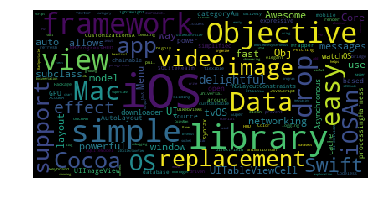

```python
wordcloud2 = WordCloud().generate(''.join(oc["Description"]))
# Generate plot
plt.imshow(wordcloud2)
plt.axis("off")
plt.show()
```

```python
popForLang('Objective-C')
```

|  | Username | Repository Name | Description | Last Update Date | Language | Number of Stars | Tags | Url |
| --- | --- | --- | --- | --- | --- | --- | --- | --- |
| 48 | AFNetworking | AFNetworking | A delightful networking framework for iOS, OS ... | 2017-06-21T18:26:52Z | Objective-C | 29400 | NaN | https://github.com/AFNetworking/AFNetworking |
| 146 | rs | SDWebImage | Asynchronous image downloader with cache suppo... | 2017-06-23T13:25:50Z | Objective-C | 18000 | NaN | https://github.com/rs/SDWebImage |
| 194 | BradLarson | GPUImage | An open source iOS framework for GPU-based ima... | 2017-06-14T10:19:49Z | Objective-C | 15900 | NaN | https://github.com/BradLarson/GPUImage |
| 216 | SnapKit | Masonry | Harness the power of AutoLayout NSLayoutConstr... | 2017-06-15T02:54:33Z | Objective-C | 15000 | NaN | https://github.com/SnapKit/Masonry |
| 274 | jdg | MBProgressHUD | MBProgressHUD + Customizations | 2017-06-02T17:44:55Z | Objective-C | 13400 | NaN | https://github.com/jdg/MBProgressHUD |
| 345 | ccgus | fmdb | A Cocoa / Objective-C wrapper around SQLite | 2017-06-15T17:00:02Z | Objective-C | 11600 | NaN | https://github.com/ccgus/fmdb |
| 375 | realm | realm-cocoa | Realm is a mobile database: a replacement for ... | 2017-06-24T03:17:03Z | Objective-C | 10900 | mobile-database,objective-c,swift,ios,sync,mob... | https://github.com/realm/realm-cocoa |
| 393 | Mantle | Mantle | Model framework for Cocoa and Cocoa Touch | 2017-04-21T16:32:46Z | Objective-C | 10600 | NaN | https://github.com/Mantle/Mantle |
| 394 | jessesquires | JSQMessagesViewController | An elegant messages UI library for iOS | 2017-06-16T14:26:58Z | Objective-C | 10600 | jsqmessagesviewcontroller,ios,messaging,messen... | https://github.com/jessesquires/JSQMessagesVie... |
| 399 | CoderMJLee | MJRefresh | An easy way to use pull-to-refresh. | 2017-05-23T07:17:23Z | Objective-C | 10500 | NaN | https://github.com/CoderMJLee/MJRefresh |
| 414 | magicalpanda | MagicalRecord | Super Awesome Easy Fetching for Core Data 1!!!... | 2017-06-05T08:19:00Z | Objective-C | 10400 | NaN | https://github.com/magicalpanda/MagicalRecord |
| 432 | alcatraz | Alcatraz | Package manager for Xcode | 2017-06-07T06:45:14Z | Objective-C | 10000 | NaN | https://github.com/alcatraz/Alcatraz |
| 447 | SVProgressHUD | SVProgressHUD | A clean and lightweight progress HUD for your ... | 2017-06-09T20:22:37Z | Objective-C | 9800 | objective-c,svprogresshud,cocoapods,carthage,t... | https://github.com/SVProgressHUD/SVProgressHUD |
| 496 | nicklockwood | iCarousel | A simple, highly customisable, data-driven 3D ... | 2017-04-26T05:55:05Z | Objective-C | 9500 | NaN | https://github.com/nicklockwood/iCarousel |
| 501 | ViccAlexander | Chameleon | Flat Color Framework for iOS (Obj-C & Swift) | 2017-06-17T03:14:17Z | Objective-C | 9400 | NaN | https://github.com/ViccAlexander/Chameleon |
| 520 | hackiftekhar | IQKeyboardManager | Codeless drop-in universal library allows to p... | 2017-06-18T05:53:08Z | Objective-C | 9200 | iqkeyboardmanager,swift,xcode,objective-c,keyb... | https://github.com/hackiftekhar/IQKeyboardManager |
| 530 | CocoaLumberjack | CocoaLumberjack | A fast & simple, yet powerful & flexible loggi... | 2017-06-08T14:08:01Z | Objective-C | 9200 | NaN | https://github.com/CocoaLumberjack/CocoaLumber... |
| 554 | airbnb | lottie-ios | An iOS library to natively render After Effect... | 2017-06-23T16:11:18Z | Objective-C | 9000 | animation,keyframes,ios,transition-animation,i... | https://github.com/airbnb/lottie-ios |
| 573 | marcuswestin | WebViewJavascriptBridge | An iOS/OSX bridge for sending messages between... | 2017-06-13T09:17:03Z | Objective-C | 8800 | NaN | https://github.com/marcuswestin/WebViewJavascr... |
| 579 | robbiehanson | CocoaAsyncSocket | Asynchronous socket networking library for Mac... | 2017-06-23T10:11:01Z | Objective-C | 8800 | NaN | https://github.com/robbiehanson/CocoaAsyncSocket |
| 582 | dzenbot | DZNEmptyDataSet | A drop-in UITableView/UICollectionView supercl... | 2017-06-08T02:26:51Z | Objective-C | 8700 | NaN | https://github.com/dzenbot/DZNEmptyDataSet |
| 600 | kevinzhow | PNChart | A simple and beautiful chart lib used in Piner... | 2017-06-17T22:47:22Z | Objective-C | 8600 | NaN | https://github.com/kevinzhow/PNChart |
| 619 | onevcat | VVDocumenter-Xcode | Xcode plug-in which helps you write documentat... | 2017-04-19T06:55:13Z | Objective-C | 8400 | NaN | https://github.com/onevcat/VVDocumenter-Xcode |
| 678 | Flipboard | FLEX | An in-app debugging and exploration tool for iOS | 2017-06-24T07:24:01Z | Objective-C | 8000 | NaN | https://github.com/Flipboard/FLEX |
| 697 | facebook | Shimmer | An easy way to add a simple, shimmering effect... | 2017-05-16T09:41:11Z | Objective-C | 7900 | NaN | https://github.com/facebook/Shimmer |
| 699 | matryer | bitbar | Put the output from any script or program in y... | 2017-06-23T10:24:19Z | Objective-C | 7900 | bitbar,menubar,mac,scripting,macosx | https://github.com/matryer/bitbar |
| 722 | eczarny | spectacle | Spectacle allows you to organize your windows ... | 2017-04-08T20:08:20Z | Objective-C | 7800 | NaN | https://github.com/eczarny/spectacle |
| 726 | slackhq | SlackTextViewController | A drop-in UIViewController subclass with a gro... | 2017-06-06T23:56:56Z | Objective-C | 7800 | NaN | https://github.com/slackhq/SlackTextViewContro... |
| 727 | forkingdog | UITableView-FDTemplateLayoutCell | Template auto layout cell for automatically UI... | 2017-05-29T09:33:50Z | Objective-C | 7800 | NaN | https://github.com/forkingdog/UITableView-FDTe... |
| 740 | OpenEmu | OpenEmu | Retro video game emulation for macOS | 2017-06-11T00:45:32Z | Objective-C | 7700 | NaN | https://github.com/OpenEmu/OpenEmu |
| 757 | Grouper | FlatUIKit | A collection of awesome flat UI components for... | 2016-09-29T04:08:55Z | Objective-C | 7600 | NaN | https://github.com/Grouper/FlatUIKit |
| 760 | TTTAttributedLabel | TTTAttributedLabel | A drop-in replacement for UILabel that support... | 2017-03-20T10:04:11Z | Objective-C | 7600 | NaN | https://github.com/TTTAttributedLabel/TTTAttri... |
| 763 | facebookarchive | three20 | Three20 is an Objective-C library for iPhone d... | 2017-05-02T06:05:12Z | Objective-C | 7600 | NaN | https://github.com/facebookarchive/three20 |
| 777 | mwaterfall | MWPhotoBrowser | A simple iOS photo and video browser with grid... | 2017-06-14T12:29:59Z | Objective-C | 7500 | NaN | https://github.com/mwaterfall/MWPhotoBrowser |
| 783 | path | FastImageCache | iOS library for quickly displaying images whil... | 2017-01-30T14:13:42Z | Objective-C | 7400 | NaN | https://github.com/path/FastImageCache |
| 854 | Aufree | trip-to-iOS | A curated list of delightful iOS resources. | 2017-06-05T09:46:10Z | Objective-C | 7000 | NaN | https://github.com/Aufree/trip-to-iOS |
| 855 | CoderMJLee | MJExtension | A fast, convenient and nonintrusive conversion... | 2017-06-02T08:02:30Z | Objective-C | 7000 | NaN | https://github.com/CoderMJLee/MJExtension |
| 862 | romaonthego | RESideMenu | iOS 7/8 style side menu with parallax effect. | 2017-04-05T13:27:49Z | Objective-C | 6900 | NaN | https://github.com/romaonthego/RESideMenu |
| 880 | facebook | SocketRocket | A conforming Objective-C WebSocket client libr... | 2017-04-17T03:34:35Z | Objective-C | 6900 | NaN | https://github.com/facebook/SocketRocket |
| 889 | CEWendel | SWTableViewCell | An easy-to-use UITableViewCell subclass that i... | 2017-04-17T09:04:08Z | Objective-C | 6800 | NaN | https://github.com/CEWendel/SWTableViewCell |
| 931 | git-up | GitUp | The Git interface you've been missing all your... | 2017-06-19T01:04:29Z | Objective-C | 6600 | NaN | https://github.com/git-up/GitUp |
| 956 | jigish | slate | A window management application (replacement f... | 2017-04-12T17:37:47Z | Objective-C | 6500 | NaN | https://github.com/jigish/slate |
| 964 | PureLayout | PureLayout | The ultimate API for iOS & OS X Auto Layout i... | 2017-05-20T17:01:23Z | Objective-C | 6500 | purelayout,ios,autolayout | https://github.com/PureLayout/PureLayout |

## Go

[figure not shown]

```python
wordcloud2 = WordCloud().generate(''.join(go["Description"]))
# Generate plot
plt.imshow(wordcloud2)
plt.axis("off")
plt.show()
```

```python
popForLang('Go')
```

|  | Username | Repository Name | Description | Last Update Date | Language | Number of Stars | Tags | Url |
| --- | --- | --- | --- | --- | --- | --- | --- | --- |
| 19 | moby | moby | Moby Project - a collaborative project for the... | 2017-06-24T19:31:46Z | Go | 44300 | docker,go,containers | https://github.com/moby/moby |
| 49 | golang | go | The Go programming language | 2017-06-24T00:54:40Z | Go | 29200 | go,programming-language,language | https://github.com/golang/go |
| 72 | kubernetes | kubernetes | Production-Grade Container Scheduling and Mana... | 2017-06-24T19:15:49Z | Go | 24300 | cncf,kubernetes,containers,go | https://github.com/kubernetes/kubernetes |
| 78 | getlantern | lantern | Lantern Latest Download https://github.com/get... | 2017-06-15T21:08:34Z | Go | 23800 | NaN | https://github.com/getlantern/lantern |
| 100 | avelino | awesome-go | A curated list of awesome Go frameworks, libra... | 2017-06-24T17:28:07Z | Go | 21600 | golang-library,go,golang,awesome,awesome-list | https://github.com/avelino/awesome-go |
| 119 | gogits | gogs | Gogs is a painless self-hosted Git service. | 2017-06-21T21:41:27Z | Go | 19700 | gogs,go,git | https://github.com/gogits/gogs |
| 144 | gohugoio | hugo | A Fast and Flexible Static Site Generator buil... | 2017-06-24T17:11:30Z | Go | 18000 | go,hugo,static-site-generator,cms,documentatio... | https://github.com/gohugoio/hugo |
| 177 | astaxie | build-web-application-with-golang | A golang ebook intro how to build a web with g... | 2017-06-19T16:30:22Z | Go | 16500 | NaN | https://github.com/astaxie/build-web-applicati... |
| 178 | grafana | grafana | The tool for beautiful monitoring and metric a... | 2017-06-24T17:02:48Z | Go | 16500 | elasticsearch,go,graphite,prometheus,grafana,i... | https://github.com/grafana/grafana |
| 185 | syncthing | syncthing | Open Source Continuous File Synchronization | 2017-06-21T05:45:24Z | Go | 16400 | go,synchronization,peer-to-peer,p2p | https://github.com/syncthing/syncthing |
| 259 | coreos | etcd | Distributed reliable key-value store for the m... | 2017-06-24T07:29:45Z | Go | 13800 | raft,etcd,go,kubernetes,distributed-systems,da... | https://github.com/coreos/etcd |
| 299 | mholt | caddy | Fast, cross-platform HTTP/2 web server with au... | 2017-06-24T18:17:07Z | Go | 12700 | caddyfile,go,tls,http,web-server,https,reverse... | https://github.com/mholt/caddy |
| 357 | astaxie | beego | beego is an open-source, high-performance web ... | 2017-06-22T11:19:08Z | Go | 11300 | go,beego | https://github.com/astaxie/beego |
| 376 | influxdata | influxdb | Scalable datastore for metrics, events, and re... | 2017-06-23T21:04:05Z | Go | 10900 | metrics,influxdb,database,monitoring,time-series | https://github.com/influxdata/influxdb |
| 378 | github | hub | hub helps you win at git. | 2017-06-23T16:53:45Z | Go | 10900 | go,homebrew,git,github-api | https://github.com/github/hub |
| 395 | cockroachdb | cockroach | CockroachDB - the open source, cloud-native SQ... | 2017-06-24T19:40:35Z | Go | 10600 | cockroachdb,sql,database,go,distributed-database | https://github.com/cockroachdb/cockroach |
| 405 | inconshreveable | ngrok | Introspected tunnels to localhost | 2017-05-04T11:52:15Z | Go | 10500 | NaN | https://github.com/inconshreveable/ngrok |
| 410 | gin-gonic | gin | Gin is a HTTP web framework written in Go (Gol... | 2017-06-19T16:54:37Z | Go | 10400 | go,middleware,performance,framework,router,server | https://github.com/gin-gonic/gin |
| 424 | drone | drone | Drone is a Continuous Delivery platform built ... | 2017-06-24T12:16:16Z | Go | 10000 | docker,go,continuous-integration,continuous-de... | https://github.com/drone/drone |
| 475 | nsqio | nsq | A realtime distributed messaging platform | 2017-06-21T17:15:43Z | Go | 9600 | go,nsq,distributed-systems,queue,messaging,mes... | https://github.com/nsqio/nsq |
| 491 | hashicorp | consul | Service Discovery and Configuration Made Easy | 2017-06-24T19:55:46Z | Go | 9500 | NaN | https://github.com/hashicorp/consul |
| 499 | go-martini | martini | Classy web framework for Go | 2017-05-27T14:41:23Z | Go | 9400 | NaN | https://github.com/go-martini/martini |
| 514 | junegunn | fzf | A command-line fuzzy finder written in Go | 2017-06-23T04:57:34Z | Go | 9300 | zsh,fish,fzf,go,vim,bash,cli,unix,neovim | https://github.com/junegunn/fzf |
| 585 | hashicorp | terraform | Terraform is a tool for building, changing, an... | 2017-06-24T15:07:21Z | Go | 8700 | graph,go,terraform,infrastructure-as-code | https://github.com/hashicorp/terraform |
| 588 | pingcap | tidb | TiDB is a distributed NewSQL database compatib... | 2017-06-24T10:16:18Z | Go | 8700 | mysql,newsql,tidb,database,scale,distributed-t... | https://github.com/pingcap/tidb |
| 599 | containous | traefik | Trfik, a modern reverse proxy | 2017-06-24T12:31:21Z | Go | 8600 | consul,etcd,microservice,marathon,docker,mesos... | https://github.com/containous/traefik |
| 617 | revel | revel | A high productivity, full-stack web framework ... | 2017-06-17T16:19:25Z | Go | 8400 | NaN | https://github.com/revel/revel |
| 654 | joewalnes | websocketd | Turn any program that uses STDIN/STDOUT into a... | 2017-06-07T09:05:41Z | Go | 8200 | websocket-server,proxy,websockets | https://github.com/joewalnes/websocketd |
| 706 | yudai | gotty | Share your terminal as a web application | 2017-05-21T23:18:28Z | Go | 7800 | go,browser,terminal,web,tty | https://github.com/yudai/gotty |
| 737 | google | grumpy | Grumpy is a Python to Go source code transcomp... | 2017-06-21T23:28:35Z | Go | 7700 | NaN | https://github.com/google/grumpy |
| 750 | labstack | echo | High performance, minimalist Go web framework | 2017-06-24T16:50:12Z | Go | 7700 | middleware,go,letsencrypt,ssl,web,microservice... | https://github.com/labstack/echo |
| 789 | buger | goreplay | GoReplay is an open-source tool for capturing ... | 2017-06-24T18:35:43Z | Go | 7400 | go,testing,devops,qa,testing-tools | https://github.com/buger/goreplay |
| 825 | minio | minio | Minio is an open source object storage server ... | 2017-06-24T20:17:29Z | Go | 7200 | go,cloud,storage,aws-s3,cloud-storage,s3-stora... | https://github.com/minio/minio |
| 836 | rkt | rkt | rkt is a pod-native container engine for Linux... | 2017-06-22T21:41:12Z | Go | 7100 | rkt,go,containers,cncf,oci,pods | https://github.com/rkt/rkt |
| 837 | go-kit | kit | A standard library for microservices. | 2017-06-23T17:33:50Z | Go | 7100 | go,golang,microservices,metallica | https://github.com/go-kit/kit |
| 849 | kataras | iris | [ACQUIRED] The fastest web framework for Go in... | 2017-06-19T18:19:20Z | Go | 7000 | iris,go,golang,cross-platform,high-performance... | https://github.com/kataras/iris |
| 856 | hashicorp | vault | A tool for managing secrets. | 2017-06-24T16:51:42Z | Go | 7000 | NaN | https://github.com/hashicorp/vault |
| 918 | hashicorp | packer | Packer is a tool for creating identical machin... | 2017-06-24T02:36:39Z | Go | 6700 | NaN | https://github.com/hashicorp/packer |
| 971 | boltdb | bolt | An embedded key/value database for Go. | 2017-06-21T09:14:46Z | Go | 6400 | go,database,key-value | https://github.com/boltdb/bolt |

## HTML

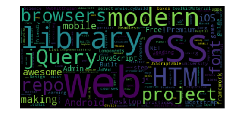

```python
wordcloud2 = WordCloud().generate(''.join(ht["Description"]))
# Generate plot
plt.imshow(wordcloud2)
plt.axis("off")
plt.show()
```

```python
popForLang('HTML')
```

|  | Username | Repository Name | Description | Last Update Date | Language | Number of Stars | Tags | Url |
| --- | --- | --- | --- | --- | --- | --- | --- | --- |
| 13 | FortAwesome | Font-Awesome | The iconic font and CSS toolkit | 2017-06-20T18:53:29Z | HTML | 50900 | NaN | https://github.com/FortAwesome/Font-Awesome |
| 56 | google | material-design-lite | Material Design Components in HTML/CSS/JS | 2017-06-23T13:58:54Z | HTML | 27800 | NaN | https://github.com/google/material-design-lite |
| 91 | ariya | phantomjs | Scriptable Headless WebKit | 2017-06-18T15:10:12Z | HTML | 22500 | NaN | https://github.com/ariya/phantomjs |
| 107 | harvesthq | chosen | Chosen is a library for making long, unwieldy ... | 2017-06-22T19:52:02Z | HTML | 20900 | NaN | https://github.com/harvesthq/chosen |
| 118 | prakhar1989 | awesome-courses | List of awesome university courses for learni... | 2017-06-19T16:18:12Z | HTML | 19800 | computer-science,awesome,courses,awesome-list | https://github.com/prakhar1989/awesome-courses |
| 147 | Polymer | polymer | Build modern apps using web components | 2017-06-23T23:59:51Z | HTML | 17800 | polymer,web-components | https://github.com/Polymer/polymer |
| 161 | Prinzhorn | skrollr | Stand-alone parallax scrolling library for mob... | 2016-08-10T13:19:54Z | HTML | 17200 | NaN | https://github.com/Prinzhorn/skrollr |
| 165 | almasaeed2010 | AdminLTE | AdminLTE - Free Premium Admin control Panel Th... | 2017-06-24T15:03:12Z | HTML | 17000 | NaN | https://github.com/almasaeed2010/AdminLTE |
| 167 | yahoo | pure | A set of small, responsive CSS modules that yo... | 2017-06-24T00:04:56Z | HTML | 17000 | html,css,pure | https://github.com/yahoo/pure |
| 174 | google | web-starter-kit | Web Starter Kit - a workflow for multi-device ... | 2017-06-08T11:49:39Z | HTML | 16600 | NaN | https://github.com/google/web-starter-kit |
| 201 | photonstorm | phaser | Phaser is a fun, free and fast 2D game framewo... | 2017-06-23T22:42:17Z | HTML | 15600 | javascript,game-frameworks,webgl,phaser,game-d... | https://github.com/photonstorm/phaser |
| 205 | usablica | intro.js | A better way for new feature introduction and ... | 2017-06-24T15:05:44Z | HTML | 15400 | javascript,html,introjs,ux,guide,tour | https://github.com/usablica/intro.js |
| 221 | ftlabs | fastclick | Polyfill to remove click delays on browsers wi... | 2017-06-13T03:16:24Z | HTML | 14800 | NaN | https://github.com/ftlabs/fastclick |
| 277 | jaywcjlove | awesome-mac | This repo is a collection of awesome Mac appl... | 2017-06-20T03:16:03Z | HTML | 13400 | macos,mac,awesome,software,macosx,awesome-list... | https://github.com/jaywcjlove/awesome-mac |
| 283 | chjj | marked | A markdown parser and compiler. Built for speed. | 2017-06-12T01:27:25Z | HTML | 13200 | NaN | https://github.com/chjj/marked |
| 301 | madrobby | zepto | Zepto.js is a minimalist JavaScript library fo... | 2017-06-23T06:25:38Z | HTML | 12600 | NaN | https://github.com/madrobby/zepto |
| 333 | desandro | masonry | Cascading grid layout library | 2017-05-11T17:17:34Z | HTML | 11900 | NaN | https://github.com/desandro/masonry |
| 356 | puikinsh | gentelella | Free Bootstrap 3 Admin Template | 2017-06-23T10:53:15Z | HTML | 11400 | bootstrap,html,dashboard,html-template,admin-d... | https://github.com/puikinsh/gentelella |
| 365 | ionic-team | ionicons | The premium icon font for Ionic | 2017-06-01T12:51:04Z | HTML | 11200 | NaN | https://github.com/ionic-team/ionicons |
| 426 | nolimits4web | Framework7 | Full featured HTML framework for building iOS ... | 2017-06-23T16:05:13Z | HTML | 10000 | android,components,ios,cordova,library,mobile,... | https://github.com/nolimits4web/Framework7 |
| 431 | octocat | Spoon-Knife | This repo is for demonstration purposes only. | 2017-06-24T05:41:57Z | HTML | 10000 | NaN | https://github.com/octocat/Spoon-Knife |
| 443 | google | styleguide | Style guides for Google-originated open-source... | 2017-06-22T21:03:25Z | HTML | 9900 | NaN | https://github.com/google/styleguide |
| 488 | keen | dashboards | Responsive dashboard templates for Bootstrap | 2017-04-27T17:11:03Z | HTML | 9500 | NaN | https://github.com/keen/dashboards |
| 535 | google | gson | A Java serialization/deserialization library t... | 2017-06-23T16:32:04Z | HTML | 9200 | NaN | https://github.com/google/gson |
| 548 | thomaspark | bootswatch | Themes for Bootstrap | 2017-06-23T18:10:23Z | HTML | 9100 | bootswatch,theme,bootstrap,css | https://github.com/thomaspark/bootswatch |
| 563 | HubSpot | youmightnotneedjquery | Updated Jun 12, 2017 | 2017-06-12T22:18:02Z | HTML | 8900 | NaN | https://github.com/HubSpot/youmightnotneedjquery |
| 630 | Microsoft | dotnet | This repo is the official home of .NET on GitH... | 2017-06-19T16:22:35Z | HTML | 8300 | NaN | https://github.com/Microsoft/dotnet |
| 634 | metafizzy | isotope | Filter & sort magical layouts | 2017-04-21T15:19:27Z | HTML | 8300 | NaN | https://github.com/metafizzy/isotope |
| 767 | google | WebFundamentals | Best practices for modern web development | 2017-06-23T22:23:23Z | HTML | 7500 | html,best-practices,javascript,css,chrome,web,... | https://github.com/google/WebFundamentals |
| 868 | hakimel | Ladda | Buttons with built-in loading indicators. | 2016-09-05T10:01:39Z | HTML | 6900 | NaN | https://github.com/hakimel/Ladda |
| 869 | TeamStuQ | skill-map | StuQ | 2017-04-23T01:09:11Z | HTML | 6900 | NaN | https://github.com/TeamStuQ/skill-map |
| 951 | tuupola | jquery_lazyload | jQuery plugin for lazy loading images | 2017-03-17T13:31:40Z | HTML | 6500 | NaN | https://github.com/tuupola/jquery_lazyload |
| 966 | mdo | code-guide | Standards for flexible, durable, and sustainab... | 2017-03-06T19:03:15Z | HTML | 6500 | NaN | https://github.com/mdo/code-guide |
| 972 | braziljs | js-the-right-way | An easy-to-read, quick reference for JS best p... | 2017-06-21T01:54:02Z | HTML | 6400 | javascript,best-practices,js,guide | https://github.com/braziljs/js-the-right-way |

## CSS

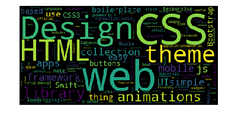

```python
wordcloud2 = WordCloud().generate(''.join(cs["Description"]))
# Generate plot
plt.imshow(wordcloud2)
plt.axis("off")
plt.show()
```

```python
popForLang('CSS')
```

|  | Username | Repository Name | Description | Last Update Date | Language | Number of Stars | Tags | Url |
| --- | --- | --- | --- | --- | --- | --- | --- | --- |
| 20 | daneden | animate.css | A cross-browser library of CSS animations. As... | 2017-06-18T06:45:18Z | CSS | 42800 | css-animations,stylesheets,css,animation | https://github.com/daneden/animate.css |
| 41 | google | material-design-icons | Material Design icons by Google | 2017-06-23T19:35:25Z | CSS | 30200 | material,sprites,icons,android,ios,web,materia... | https://github.com/google/material-design-icons |
| 61 | necolas | normalize.css | A collection of HTML element and attribute sty... | 2017-06-15T19:41:13Z | CSS | 26700 | NaN | https://github.com/necolas/normalize.css |
| 114 | sahat | hackathon-starter | A boilerplate for Node.js web applications | 2017-06-18T21:55:28Z | CSS | 20100 | hackathon,nodejs,boilerplate,oauth2 | https://github.com/sahat/hackathon-starter |
| 140 | FezVrasta | bootstrap-material-design | Material design theme for Bootstrap 3 and 4 | 2017-05-09T21:33:21Z | CSS | 18300 | NaN | https://github.com/FezVrasta/bootstrap-materia... |
| 166 | numbbbbb | the-swift-programming-language-in-chinese | Apple Swift The Swift Programming Language | 2017-05-31T04:16:03Z | CSS | 17000 | NaN | https://github.com/numbbbbb/the-swift-programm... |
| 169 | IanLunn | Hover | A collection of CSS3 powered hover effects to ... | 2017-04-06T16:27:26Z | CSS | 16900 | css,css-effects,sass | https://github.com/IanLunn/Hover |
| 180 | jgthms | bulma | Modern CSS framework based on Flexbox | 2017-06-21T14:05:03Z | CSS | 16500 | flexbox,css,html,design,css-framework | https://github.com/jgthms/bulma |
| 213 | Tencent | weui | A UI library by WeChat official design team, i... | 2017-06-22T07:03:17Z | CSS | 15100 | NaN | https://github.com/Tencent/weui |
| 245 | dhg | Skeleton | Skeleton: A Dead Simple, Responsive Boilerplat... | 2017-05-17T19:20:37Z | CSS | 14200 | NaN | https://github.com/dhg/Skeleton |
| 246 | FreeCodeCampChina | freecodecamp.cn | CodeIssuesPull requestsWiki^_^ | 2017-06-22T03:10:06Z | CSS | 14200 | NaN | https://github.com/FreeCodeCampChina/freecodec... |
| 257 | twbs | ratchet | Build mobile apps with simple HTML, CSS, and J... | 2017-03-06T12:00:32Z | CSS | 13900 | ratchet,javascript,css,html | https://github.com/twbs/ratchet |
| 276 | tobiasahlin | SpinKit | A collection of loading indicators animated wi... | 2017-04-20T17:58:49Z | CSS | 13400 | NaN | https://github.com/tobiasahlin/SpinKit |
| 286 | designmodo | Flat-UI | Flat UI Free - Design Framework (html/css3/les... | 2017-02-21T20:29:33Z | CSS | 13100 | NaN | https://github.com/designmodo/Flat-UI |
| 325 | HubSpot | pace | Automatically add a progress bar to your site.... | 2017-05-15T19:42:17Z | CSS | 12100 | NaN | https://github.com/HubSpot/pace |
| 371 | h5bp | Effeckt.css | A Performant Transitions and Animations Library | 2016-03-27T15:29:44Z | CSS | 11000 | NaN | https://github.com/h5bp/Effeckt.css |
| 386 | chriskempson | tomorrow-theme | Tomorrow Theme the precursor to Base16 Theme | 2017-03-09T03:49:36Z | CSS | 10700 | NaN | https://github.com/chriskempson/tomorrow-theme |
| 448 | uikit | uikit | A lightweight and modular front-end framework ... | 2017-06-22T16:20:51Z | CSS | 9800 | NaN | https://github.com/uikit/uikit |
| 561 | you-dont-need | You-Dont-Need-JavaScript | CSS is powerful, you can do a lot of things wi... | 2017-05-23T11:15:27Z | CSS | 9000 | textfield,tooltip,treeview,accordion,counter,b... | https://github.com/you-dont-need/You-Dont-Need... |
| 568 | gabrielecirulli | 2048 | A small clone of 1024 (https://play.google.com... | 2017-06-08T00:25:56Z | CSS | 8900 | NaN | https://github.com/gabrielecirulli/2048 |
| 577 | jessepollak | card | make your credit card form better in one line... | 2017-06-06T13:16:21Z | CSS | 8800 | jquery,javascript,credit-card,css,coffeescript... | https://github.com/jessepollak/card |
| 738 | HubSpot | offline | Automatically display online/offline indicatio... | 2017-05-26T19:43:28Z | CSS | 7700 | NaN | https://github.com/HubSpot/offline |
| 762 | Automattic | _s | Hi. I'm a starter theme called _s, or undersco... | 2017-06-23T17:16:38Z | CSS | 7600 | NaN | https://github.com/Automattic/_s |
| 782 | mrmrs | colors | Smarter defaults for colors on the web. | 2017-02-28T02:22:22Z | CSS | 7400 | NaN | https://github.com/mrmrs/colors |
| 785 | ConnorAtherton | loaders.css | Delightful, performance-focused pure css loadi... | 2017-03-22T00:30:09Z | CSS | 7400 | NaN | https://github.com/ConnorAtherton/loaders.css |
| 792 | chinchang | hint.css | A CSS only tooltip library for your lovely web... | 2017-06-22T22:18:06Z | CSS | 7400 | tooltip,bem,css,tooltip-library,accessibility,... | https://github.com/chinchang/hint.css |
| 835 | connors | photon | The fastest way to build beautiful Electron ap... | 2017-02-24T05:27:08Z | CSS | 7100 | electron,photon,css,html | https://github.com/connors/photon |
| 864 | Compass | compass | Compass is no longer actively maintained. Comp... | 2017-05-24T15:51:30Z | CSS | 6900 | NaN | https://github.com/Compass/compass |
| 888 | fronteed | icheck | Highly customizable checkboxes and radio butto... | 2017-05-07T15:25:03Z | CSS | 6800 | NaN | https://github.com/fronteed/icheck |
| 924 | ubuwaits | beautiful-web-type | A showcase of the best typefaces from the Goog... | 2016-11-02T09:07:24Z | CSS | 6600 | NaN | https://github.com/ubuwaits/beautiful-web-type |

## Swift

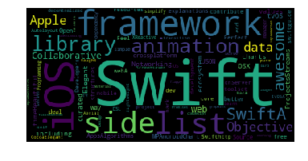

```python
wordcloud2 = WordCloud().generate(''.join(sw["Description"]))
# Generate plot
plt.imshow(wordcloud2)
plt.axis("off")
plt.show()
```

```python
popForLang('Swift')
```

|  | Username | Repository Name | Description | Last Update Date | Language | Number of Stars | Tags | Url |
| --- | --- | --- | --- | --- | --- | --- | --- | --- |
| 74 | Alamofire | Alamofire | Elegant HTTP Networking in Swift | 2017-06-18T16:52:42Z | Swift | 24100 | NaN | https://github.com/Alamofire/Alamofire |
| 112 | vsouza | awesome-ios | A curated list of awesome iOS ecosystem, inclu... | 2017-06-24T15:50:09Z | Swift | 20400 | swift-wrapper,xcode-plugin,ios-animation,swift... | https://github.com/vsouza/awesome-ios |
| 156 | ReactiveCocoa | ReactiveCocoa | Streams of values over time | 2017-06-21T02:49:58Z | Swift | 17400 | reactiveswift,swift,reactivecocoa | https://github.com/ReactiveCocoa/ReactiveCocoa |
| 220 | danielgindi | Charts | Beautiful charts for iOS/tvOS/OSX! The Apple s... | 2017-06-19T05:37:00Z | Swift | 14900 | NaN | https://github.com/danielgindi/Charts |
| 225 | SwiftyJSON | SwiftyJSON | The better way to deal with JSON data in Swift | 2017-06-04T15:06:51Z | Swift | 14800 | swiftyjson,json | https://github.com/SwiftyJSON/SwiftyJSON |
| 268 | dkhamsing | open-source-ios-apps | Collaborative List of Open-Source iOS Apps | 2017-06-21T16:37:43Z | Swift | 13600 | game,swift,ios,app,list,apple,awesome,react-na... | https://github.com/dkhamsing/open-source-ios-apps |
| 289 | raywenderlich | swift-algorithm-club | Algorithms and data structures in Swift, with ... | 2017-06-24T16:07:07Z | Swift | 13000 | NaN | https://github.com/raywenderlich/swift-algorit... |
| 318 | matteocrippa | awesome-swift | A collaborative list of awesome swift resource... | 2017-06-24T19:01:15Z | Swift | 12300 | swift,swift-language,swift-library,lists,list,... | https://github.com/matteocrippa/awesome-swift |
| 332 | ipader | SwiftGuide | Swifthttp://dev.swiftguide.cn | 2017-06-05T05:44:05Z | Swift | 12000 | NaN | https://github.com/ipader/SwiftGuide |
| 336 | PerfectlySoft | Perfect | Server-side Swift. The Perfect core toolset an... | 2017-05-31T17:08:16Z | Swift | 11700 | swift,swift-perfect-community,perfect,swift-fr... | https://github.com/PerfectlySoft/Perfect |
| 377 | MengTo | Spring | A library to simplify iOS animations in Swift. | 2017-06-23T07:29:48Z | Swift | 10900 | NaN | https://github.com/MengTo/Spring |
| 421 | vapor | vapor | A server-side Swift web framework. | 2017-06-24T16:13:58Z | Swift | 10000 | vapor,swift,framework,server,web-framework,ser... | https://github.com/vapor/vapor |
| 423 | SnapKit | SnapKit | A Swift Autolayout DSL for iOS & OS X | 2017-06-12T10:15:39Z | Swift | 10000 | dsl,swift,xcode,cocoapods,snapkit,ui,layout,co... | https://github.com/SnapKit/SnapKit |
| 462 | ReactiveX | RxSwift | Reactive Programming in Swift | 2017-06-22T10:43:07Z | Swift | 9700 | rxswift,reactivex,swift,ios,reactive,unidirect... | https://github.com/ReactiveX/RxSwift |
| 470 | Carthage | Carthage | A simple, decentralized dependency manager for... | 2017-06-24T19:22:27Z | Swift | 9700 | carthage,swift,package-manager,cocoa | https://github.com/Carthage/Carthage |
| 516 | lkzhao | Hero | Elegant transition library for iOS & tvOS | 2017-06-23T21:11:20Z | Swift | 9300 | animation,custom-transitions,swift,ios,materia... | https://github.com/lkzhao/Hero |
| 559 | allenwong | 30DaysofSwift | A self-taught project to learn Swift. | 2017-04-18T08:30:58Z | Swift | 9000 | NaN | https://github.com/allenwong/30DaysofSwift |
| 572 | JohnCoates | Aerial | Apple TV Aerial Screensaver for Mac | 2017-06-10T12:11:27Z | Swift | 8800 | NaN | https://github.com/JohnCoates/Aerial |
| 576 | onevcat | Kingfisher | A lightweight, pure-Swift library for download... | 2017-06-22T03:05:50Z | Swift | 8800 | swift,kingfisher,image,cache | https://github.com/onevcat/Kingfisher |
| 616 | fullstackio | FlappySwift | swift implementation of flappy bird. More at f... | 2017-06-21T12:00:27Z | Swift | 8400 | NaN | https://github.com/fullstackio/FlappySwift |
| 651 | ochococo | Design-Patterns-In-Swift | Design Patterns implemented in Swift | 2017-06-17T17:28:44Z | Swift | 8200 | swift,computer-science,playground,design-patte... | https://github.com/ochococo/Design-Patterns-In... |
| 672 | CosmicMind | Material | An animation and graphics framework for Materi... | 2017-06-23T22:56:23Z | Swift | 8000 | snackbar,material,navigation-controller,card,n... | https://github.com/CosmicMind/Material |
| 717 | mxcl | PromiseKit | Promises for Swift & ObjC | 2017-06-23T19:00:53Z | Swift | 7800 | NaN | https://github.com/mxcl/PromiseKit |
| 797 | Ramotion | animated-tab-bar | RAMAnimatedTabBarController is a Swift module ... | 2017-04-07T06:44:24Z | Swift | 7400 | uitabbarcontroller,cocoapods,animation,swift,i... | https://github.com/Ramotion/animated-tab-bar |
| 822 | mozilla-mobile | firefox-ios | Firefox for iOS | 2017-06-24T18:47:05Z | Swift | 7200 | swift,firefox,browser,mozilla,ios-app | https://github.com/mozilla-mobile/firefox-ios |
| 841 | realm | SwiftLint | A tool to enforce Swift style and conventions. | 2017-06-24T19:17:15Z | Swift | 7000 | NaN | https://github.com/realm/SwiftLint |
| 944 | Quick | Quick | The Swift (and Objective-C) testing framework. | 2017-06-22T06:56:09Z | Swift | 6600 | cocoapods,swift,objective-c,carthage,testing,bdd | https://github.com/Quick/Quick |
| 979 | lhc70000 | iina | The modern video player for macOS. | 2017-06-24T19:09:31Z | Swift | 6400 | macos,video,mpv,swift,video-player | https://github.com/lhc70000/iina |

## C+

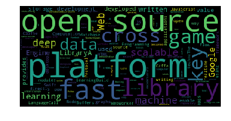

```python
wordcloud2 = WordCloud().generate(''.join(cp["Description"]))
# Generate plot
plt.imshow(wordcloud2)
plt.axis("off")
plt.show()
```

```python
popForLang('C++')
```

|  | Username | Repository Name | Description | Last Update Date | Language | Number of Stars | Tags | Url |
| --- | --- | --- | --- | --- | --- | --- | --- | --- |
| 6 | tensorflow | tensorflow | Computation using data flow graphs for scalabl... | 2017-06-24T18:25:42Z | C++ | 61600 | tensorflow,python,machine-learning,deep-neural... | https://github.com/tensorflow/tensorflow |
| 15 | electron | electron | Build cross platform desktop apps with JavaScr... | 2017-06-24T11:58:28Z | C++ | 47200 | html,css,javascript,electron,c-plus-plus,chrom... | https://github.com/electron/electron |
| 21 | apple | swift | The Swift Programming Language | 2017-06-24T19:10:06Z | C++ | 39100 | NaN | https://github.com/apple/swift |
| 38 | nwjs | nw.js | Call all Node.js modules directly from DOM/Web... | 2017-06-23T05:35:29Z | C++ | 31800 | intel,node-webkit,nwjs,javascript,desktop,web-... | https://github.com/nwjs/nw.js |
| 127 | rethinkdb | rethinkdb | The open-source database for the realtime web. | 2017-06-22T21:33:37Z | C++ | 19200 | NaN | https://github.com/rethinkdb/rethinkdb |
| 135 | BVLC | caffe | Caffe: a fast open framework for deep learning. | 2017-06-24T05:44:36Z | C++ | 18700 | NaN | https://github.com/BVLC/caffe |
| 142 | google | protobuf | Protocol Buffers - Google's data interchange f... | 2017-06-24T19:20:57Z | C++ | 18200 | protobuf-runtime,protocol-compiler,protobuf,pr... | https://github.com/google/protobuf |
| 183 | opencv | opencv | Open Source Computer Vision Library | 2017-06-24T08:38:33Z | C++ | 16400 | opencv,c-plus-plus,computer-vision,deep-learni... | https://github.com/opencv/opencv |
| 235 | facebook | hhvm | A virtual machine designed for executing progr... | 2017-06-24T05:24:40Z | C++ | 14600 | hhvm,hack,php,hacklang | https://github.com/facebook/hhvm |
| 263 | bitcoin | bitcoin | Bitcoin Core integration/staging tree | 2017-06-24T14:40:11Z | C++ | 13700 | bitcoin,c-plus-plus,cryptography,p2p,cryptocur... | https://github.com/bitcoin/bitcoin |
| 337 | mongodb | mongo | The MongoDB Database | 2017-06-24T16:14:51Z | C++ | 11700 | NaN | https://github.com/mongodb/mongo |
| 350 | Microsoft | CNTK | Microsoft Cognitive Toolkit (CNTK), an open so... | 2017-06-24T18:28:09Z | C++ | 11500 | NaN | https://github.com/Microsoft/CNTK |
| 362 | tesseract-ocr | tesseract | Tesseract Open Source OCR Engine (main reposit... | 2017-06-23T16:26:22Z | C++ | 11200 | ocr-engine,tesseract,tesseract-ocr,machine-lea... | https://github.com/tesseract-ocr/tesseract |
| 409 | cocos2d | cocos2d-x | Cocos2d-x is a suite of open-source, cross-pla... | 2017-06-24T15:52:32Z | C++ | 10400 | cocos2d,c-plus-plus,cocos2d-js,javascript,lua,... | https://github.com/cocos2d/cocos2d-x |
| 436 | google | guetzli | Perceptual JPEG encoder | 2017-06-21T05:18:44Z | C++ | 9900 | jpeg-encoder | https://github.com/google/guetzli |
| 456 | facebookresearch | fastText | Library for fast text representation and class... | 2017-06-09T18:57:13Z | C++ | 9800 | NaN | https://github.com/facebookresearch/fastText |
| 464 | google | leveldb | LevelDB is a fast key-value storage library wr... | 2017-06-15T07:16:50Z | C++ | 9700 | NaN | https://github.com/google/leveldb |
| 517 | facebook | osquery | SQL powered operating system instrumentation, ... | 2017-06-24T08:10:03Z | C++ | 9300 | monitoring,sql,security,intrusion-detection | https://github.com/facebook/osquery |
| 556 | Tencent | mars | Mars is a cross-platform network component dev... | 2017-06-20T03:38:21Z | C++ | 9000 | cross-platform,wechat,log,network | https://github.com/Tencent/mars |
| 580 | facebook | folly | An open-source C++ library developed and used ... | 2017-06-24T03:28:07Z | C++ | 8800 | NaN | https://github.com/facebook/folly |
| 609 | godotengine | godot | Godot Engine Multi-platform 2D and 3D game en... | 2017-06-24T16:18:17Z | C++ | 8500 | godot,open-source,gamedev,multi-platform,game-... | https://github.com/godotengine/godot |
| 689 | google | flatbuffers | Memory Efficient Serialization Library | 2017-06-23T00:04:59Z | C++ | 7900 | NaN | https://github.com/google/flatbuffers |
| 694 | facebook | rocksdb | A library that provides an embeddable, persist... | 2017-06-24T01:30:05Z | C++ | 7900 | NaN | https://github.com/facebook/rocksdb |
| 744 | dmlc | xgboost | Scalable, Portable and Distributed Gradient Bo... | 2017-06-24T16:39:56Z | C++ | 7700 | gbdt,xgboost,gbm,distributed-systems,gbrt | https://github.com/dmlc/xgboost |
| 796 | uNetworking | uWebSockets | Tiny WebSockets | 2017-06-23T22:48:45Z | C++ | 7400 | websockets,http | https://github.com/uNetworking/uWebSockets |
| 820 | ocornut | imgui | Bloat-free Immediate Mode Graphical User inter... | 2017-06-24T11:11:52Z | C++ | 7200 | gamedev,gui,imgui | https://github.com/ocornut/imgui |
| 843 | CRYTEK | CRYENGINE | CRYENGINE is a powerful real-time game develop... | 2017-06-23T19:35:46Z | C++ | 7000 | c-plus-plus,gamedev,multi-platform,cross-platf... | https://github.com/CRYTEK/CRYENGINE |
| 968 | mobile-shell | mosh | Mobile Shell | 2017-06-02T14:24:59Z | C++ | 6500 | NaN | https://github.com/mobile-shell/mosh |

```python
# sns.barplot(x=clean_df["Language"], y=clean_df["Number of Stars"], data=clean_df, order=pd.value_counts(clean_df['Language']).iloc[:10].index)
```

# K-MEAN Clustering

## Copy clean_df to kmean_df for the K-Mean Clustering

```python
kmean_df = clean_df.copy()
```

```python
kmean_df.head()
```

|  | Username | Repository Name | Description | Last Update Date | Language | Number of Stars | Tags | Url |
| --- | --- | --- | --- | --- | --- | --- | --- | --- |
| 0 | freeCodeCamp | freeCodeCamp | The https://freeCodeCamp.com open source codeb... | 2017-06-24T15:56:17Z | JavaScript | 290000 | nonprofits,certification,curriculum,react,node... | https://github.com/freeCodeCamp/freeCodeCamp |
| 1 | twbs | bootstrap | The most popular HTML, CSS, and JavaScript fra... | 2017-06-24T15:40:21Z | JavaScript | 112000 | javascript,css,html,bootstrap,jekyll-site,scss | https://github.com/twbs/bootstrap |
| 3 | facebook | react | A declarative, efficient, and flexible JavaScr... | 2017-06-24T19:33:49Z | JavaScript | 69700 | NaN | https://github.com/facebook/react |
| 4 | d3 | d3 | Bring data to life with SVG, Canvas and HTML. | 2017-05-31T06:03:47Z | JavaScript | 65700 | visualization | https://github.com/d3/d3 |
| 5 | getify | You-Dont-Know-JS | A book series on JavaScript. @YDKJS on twitter. | 2017-06-23T10:42:36Z | JavaScript | 62000 | book-series,javascript,training-materials,asyn... | https://github.com/getify/You-Dont-Know-JS |

## Generate the Language from str to int

```python
pd.value_counts(kmean_df['Language'].values, sort = True)
```

```
JavaScript          338
Java                 67
Python               62
Ruby                 44
Objective-C          43
Go                   39
HTML                 34
CSS                  30
C++                  28
Swift                28
C                    26
PHP                  23
Shell                20
TypeScript           15
Vim script           14
C#                    9
CoffeeScript          7
Scala                 5
Vue                   5
Lua                   4
Elixir                3
Objective-C++         3
Clojure               3
Jupyter Notebook      3
TeX                   3
Haskell               3
OCaml                 2
Perl                  2
Rust                  2
PowerShell            2
Assembly              1
Rascal                1
Crystal               1
PureBasic             1
Batchfile             1
Emacs Lisp            1
Kotlin                1
Julia                 1
Matlab                1
dtype: int64
```

## Label Encoder

```python
le_encoders = {}
le = LabelEncoder()
le_encoders["Language"] = le
kmean_df["Language"] = le.fit_transform(kmean_df["Language"])
```

```python
pd.value_counts(kmean_df['Language'].values, sort = True)
```

```
15    338
14     67
28     62
30     44
22     43
11     39
12     34
5      30
4      28
34     28
2      26
24     23
33     20
36     15
37     14
```

[output cut: 25 more lines]

```python
kmean_df.head()
```

|  | Username | Repository Name | Description | Last Update Date | Language | Number of Stars | Tags | Url |
| --- | --- | --- | --- | --- | --- | --- | --- | --- |
| 0 | freeCodeCamp | freeCodeCamp | The https://freeCodeCamp.com open source codeb... | 2017-06-24T15:56:17Z | 15 | 290000 | nonprofits,certification,curriculum,react,node... | https://github.com/freeCodeCamp/freeCodeCamp |
| 1 | twbs | bootstrap | The most popular HTML, CSS, and JavaScript fra... | 2017-06-24T15:40:21Z | 15 | 112000 | javascript,css,html,bootstrap,jekyll-site,scss | https://github.com/twbs/bootstrap |
| 3 | facebook | react | A declarative, efficient, and flexible JavaScr... | 2017-06-24T19:33:49Z | 15 | 69700 | NaN | https://github.com/facebook/react |
| 4 | d3 | d3 | Bring data to life with SVG, Canvas and HTML. | 2017-05-31T06:03:47Z | 15 | 65700 | visualization | https://github.com/d3/d3 |
| 5 | getify | You-Dont-Know-JS | A book series on JavaScript. @YDKJS on twitter. | 2017-06-23T10:42:36Z | 15 | 62000 | book-series,javascript,training-materials,asyn... | https://github.com/getify/You-Dont-Know-JS |

```python
kmean_df['Number of Stars']=kmean_df['Number of Stars'].astype("float64")
kmean_df['Language']=kmean_df['Language'].astype("float64")
```

```python
kmean_df.dtypes
```

```
Username             object
Repository Name      object
Description          object
Last Update Date     object
Language            float64
Number of Stars     float64
Tags                 object
Url                  object
dtype: object
```

## Drop unusable column for K-Mean Clustering

```python
X = kmean_df.drop(['Username','Repository Name','Description','Last Update Date','Tags','Url'], axis=1)
X
```

|  | Language | Number of Stars |
| --- | --- | --- |
| 0 | 15.0 | 290000.0 |
| 1 | 15.0 | 112000.0 |
| 3 | 15.0 | 69700.0 |
| 4 | 15.0 | 65700.0 |
| 5 | 15.0 | 62000.0 |
| 6 | 4.0 | 61600.0 |
| 8 | 15.0 | 57700.0 |
| 9 | 15.0 | 56200.0 |
| 10 | 33.0 | 55200.0 |
| 11 | 15.0 | 54100.0 |
| 13 | 12.0 | 50900.0 |
| 14 | 15.0 | 50000.0 |
| 15 | 4.0 | 47200.0 |
| 16 | 2.0 | 46300.0 |
| 17 | 15.0 | 45300.0 |
| 19 | 11.0 | 44300.0 |
| 20 | 5.0 | 42800.0 |
| 21 | 4.0 | 39100.0 |
| 22 | 7.0 | 37800.0 |
| 23 | 15.0 | 37700.0 |
| 24 | 15.0 | 37600.0 |
| 25 | 15.0 | 36400.0 |
| 27 | 30.0 | 36100.0 |
| 28 | 15.0 | 35600.0 |
| 29 | 28.0 | 35300.0 |
| 30 | 15.0 | 35200.0 |
| 31 | 15.0 | 33800.0 |
| 32 | 15.0 | 33600.0 |
| 33 | 24.0 | 32900.0 |
| 34 | 15.0 | 32500.0 |
| ... | ... | ... |
| 948 | 7.0 | 6500.0 |
| 949 | 36.0 | 6500.0 |
| 950 | 15.0 | 6500.0 |
| 951 | 12.0 | 6500.0 |
| 952 | 15.0 | 6500.0 |
| 953 | 24.0 | 6500.0 |
| 954 | 33.0 | 6500.0 |
| 955 | 28.0 | 6500.0 |
| 956 | 22.0 | 6500.0 |
| 957 | 2.0 | 6500.0 |
| 958 | 15.0 | 6500.0 |
| 959 | 15.0 | 6500.0 |
| 962 | 15.0 | 6500.0 |
| 963 | 18.0 | 6500.0 |
| 964 | 22.0 | 6500.0 |
| 965 | 14.0 | 6500.0 |
| 966 | 12.0 | 6500.0 |
| 967 | 28.0 | 6500.0 |
| 968 | 4.0 | 6500.0 |
| 969 | 15.0 | 6400.0 |
| 970 | 33.0 | 6400.0 |
| 971 | 11.0 | 6400.0 |
| 972 | 12.0 | 6400.0 |
| 973 | 15.0 | 6400.0 |
| 974 | 15.0 | 6400.0 |
| 975 | 14.0 | 6400.0 |
| 976 | 28.0 | 6400.0 |
| 977 | 2.0 | 6400.0 |
| 978 | 38.0 | 6400.0 |
| 979 | 34.0 | 6400.0 |

876 rows × 2 columns

## Using Machine Learning to Plot line graph

```python
X_scale = StandardScaler().fit_transform(X)
```

```python
ks = []
costs = []
for k in range(2, 13):
    kmeans = KMeans(n_clusters=k).fit(X_scale)
    ks.append(k)
    costs.append(kmeans.inertia_)
```

```python
sns.set_style("whitegrid",{'grid.linestyle':'--'})
```

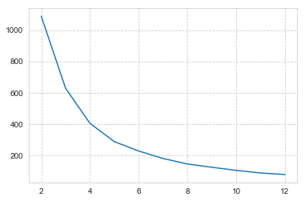

```python
sns.lineplot(x=ks, y=costs)
```

```python
kmeans = KMeans(n_clusters=5).fit(X)
```

```python
km = pd.DataFrame(kmeans.labels_, columns=['cluster'])
df_km = pd.concat([kmean_df, km], axis=1)
```

```python
df_km.head()
```

|  | Username | Repository Name | Description | Last Update Date | Language | Number of Stars | Tags | Url | cluster |
| --- | --- | --- | --- | --- | --- | --- | --- | --- | --- |
| 0 | freeCodeCamp | freeCodeCamp | The https://freeCodeCamp.com open source codeb... | 2017-06-24T15:56:17Z | 15.0 | 290000.0 | nonprofits,certification,curriculum,react,node... | https://github.com/freeCodeCamp/freeCodeCamp | 1.0 |
| 1 | twbs | bootstrap | The most popular HTML, CSS, and JavaScript fra... | 2017-06-24T15:40:21Z | 15.0 | 112000.0 | javascript,css,html,bootstrap,jekyll-site,scss | https://github.com/twbs/bootstrap | 3.0 |
| 2 | NaN | NaN | NaN | NaN | NaN | NaN | NaN | NaN | 3.0 |
| 3 | facebook | react | A declarative, efficient, and flexible JavaScr... | 2017-06-24T19:33:49Z | 15.0 | 69700.0 | NaN | https://github.com/facebook/react | 3.0 |
| 4 | d3 | d3 | Bring data to life with SVG, Canvas and HTML. | 2017-05-31T06:03:47Z | 15.0 | 65700.0 | visualization | https://github.com/d3/d3 | 3.0 |

```python
x = df_km.drop(['Username','Repository Name','Description','Last Update Date','Tags','Url'], axis=1)
```

```python
x = x.dropna()
```

```python
pca = PCA(n_components=2)
principalComponents = pca.fit_transform(x)
principalDf = pd.DataFrame(data = principalComponents, columns = ['xaxis', 'yaxis'])
```

```python
finalDf = pd.concat([principalDf, km], axis = 1)
```

```python
finalDf.head()
```

|  | xaxis | yaxis | cluster |
| --- | --- | --- | --- |
| 0 | 276429.102246 | 5.799066 | 1 |
| 1 | 98429.102589 | 0.335461 | 3 |
| 2 | 56129.102650 | -0.962732 | 3 |
| 3 | 52129.102656 | -1.085493 | 3 |
| 4 | 48429.102661 | -1.199047 | 3 |

```python
pd.value_counts(finalDf['cluster'].values, sort = True)
```

```
0    592
4    203
2     65
3     15
1      1
dtype: int64
```

## Scatter Plot

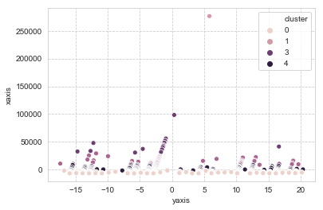

```python
sns.scatterplot(y='xaxis', x='yaxis', hue='cluster', data=finalDf)
```

## Cluster 0 [info]

```python
df_cluster0 = df_km[df_km['cluster'] == 0]
```

```python
df_cluster0
```

|  | Username | Repository Name | Description | Last Update Date | Language | Number of Stars | Tags | Url | cluster |
| --- | --- | --- | --- | --- | --- | --- | --- | --- | --- |
| 284 | knsv | mermaid | Generation of diagram and flowchart from text ... | 2017-06-04T07:26:58Z | 15.0 | 13200.0 | NaN | https://github.com/knsv/mermaid | 0.0 |
| 285 | juliangarnier | anime | JavaScript Animation Engine | 2017-06-24T15:44:51Z | 15.0 | 13100.0 | anime,animation | https://github.com/juliangarnier/anime | 0.0 |
| 286 | designmodo | Flat-UI | Flat UI Free - Design Framework (html/css3/les... | 2017-02-21T20:29:33Z | 5.0 | 13100.0 | NaN | https://github.com/designmodo/Flat-UI | 0.0 |
| 287 | julianshapiro | velocity | Accelerated JavaScript animation. | 2017-05-12T13:58:42Z | 15.0 | 13100.0 | NaN | https://github.com/julianshapiro/velocity | 0.0 |
| 288 | NaN | NaN | NaN | NaN | NaN | NaN | NaN | NaN | 0.0 |
| 289 | raywenderlich | swift-algorithm-club | Algorithms and data structures in Swift, with ... | 2017-06-24T16:07:07Z | 34.0 | 13000.0 | NaN | https://github.com/raywenderlich/swift-algorit... | 0.0 |
| 290 | postcss | autoprefixer | Parse CSS and add vendor prefixes to rules by ... | 2017-06-19T15:07:16Z | 15.0 | 13000.0 | postcss-plugins,css,prefixer | https://github.com/postcss/autoprefixer | 0.0 |
| 291 | getsentry | sentry | Sentry is a cross-platform crash reporting and... | 2017-06-24T18:38:04Z | 28.0 | 13000.0 | python,devops,django,monitoring,crash-reportin... | https://github.com/getsentry/sentry | 0.0 |
| 292 | angular | angular-seed | Seed project for angular apps. | 2017-05-19T06:14:57Z | 15.0 | 13000.0 | NaN | https://github.com/angular/angular-seed | 0.0 |
| 293 | npm | npm | a package manager for javascript | 2017-06-23T20:08:48Z | 15.0 | 12900.0 | NaN | https://github.com/npm/npm | 0.0 |
| 294 | facebook | fresco | An Android library for managing images and the... | 2017-06-22T12:38:18Z | 14.0 | 12900.0 | NaN | https://github.com/facebook/fresco | 0.0 |
| 295 | hubotio | hubot | A customizable life embetterment robot. | 2017-06-23T21:46:33Z | 15.0 | 12800.0 | hubot,chat,bot | https://github.com/hubotio/hubot | 0.0 |
| 296 | domnikl | DesignPatternsPHP | sample code for several design patterns in PHP | 2017-05-31T09:15:27Z | 24.0 | 12800.0 | php,designpatternsphp,design-pattern,oop,phpun... | https://github.com/domnikl/DesignPatternsPHP | 0.0 |
| 297 | ReactiveX | RxAndroid | RxJava bindings for Android | 2017-05-06T19:59:03Z | 14.0 | 12800.0 | NaN | https://github.com/ReactiveX/RxAndroid | 0.0 |
| 298 | NaN | NaN | NaN | NaN | NaN | NaN | NaN | NaN | 0.0 |
| 299 | mholt | caddy | Fast, cross-platform HTTP/2 web server with au... | 2017-06-24T18:17:07Z | 11.0 | 12700.0 | caddyfile,go,tls,http,web-server,https,reverse... | https://github.com/mholt/caddy | 0.0 |
| 300 | nolimits4web | Swiper | Most modern mobile touch slider with hardware ... | 2017-06-06T13:31:45Z | 15.0 | 12700.0 | swipe,gallery,mobile,slider,touch,carousel,tou... | https://github.com/nolimits4web/Swiper | 0.0 |
| 301 | madrobby | zepto | Zepto.js is a minimalist JavaScript library fo... | 2017-06-23T06:25:38Z | 12.0 | 12600.0 | NaN | https://github.com/madrobby/zepto | 0.0 |
| 302 | mochajs | mocha | simple, flexible, fun javascript test framewo... | 2017-06-23T15:59:08Z | 15.0 | 12600.0 | javascript,mocha,nodejs,testing,browser,tdd,bd... | https://github.com/mochajs/mocha | 0.0 |
| 303 | Automattic | mongoose | MongoDB object modeling designed to work in an... | 2017-06-24T01:58:19Z | 15.0 | 12600.0 | NaN | https://github.com/Automattic/mongoose | 0.0 |
| 304 | wg | wrk | Modern HTTP benchmarking tool | 2017-05-04T16:06:49Z | 2.0 | 12600.0 | NaN | https://github.com/wg/wrk | 0.0 |
| 305 | ggreer | the_silver_searcher | A code-searching tool similar to ack, but faster. | 2017-06-23T23:25:48Z | 2.0 | 12600.0 | c,silver-searcher,pcre,command-line-tool,ag,se... | https://github.com/ggreer/the_silver_searcher | 0.0 |
| 306 | jlmakes | scrollreveal | Easy scroll animations for web and mobile brow... | 2017-06-23T15:13:03Z | 15.0 | 12600.0 | javascript,animation,scroll,reveal | https://github.com/jlmakes/scrollreveal | 0.0 |
| 307 | jasmine | jasmine | Simple JavaScript testing framework for browse... | 2017-06-22T08:51:20Z | 15.0 | 12600.0 | NaN | https://github.com/jasmine/jasmine | 0.0 |
| 308 | cheeriojs | cheerio | Fast, flexible, and lean implementation of cor... | 2017-06-24T17:39:39Z | 15.0 | 12500.0 | NaN | https://github.com/cheeriojs/cheerio | 0.0 |
| 309 | NaN | NaN | NaN | NaN | NaN | NaN | NaN | NaN | 0.0 |
| 310 | enyo | dropzone | Dropzone is an easy to use drag'n'drop library... | 2017-06-20T13:40:48Z | 15.0 | 12500.0 | dropzone,javascript,coffeescript,drag-and-drop... | https://github.com/enyo/dropzone | 0.0 |
| 311 | CamDavidsonPilon | Probabilistic-Programming-and-Bayesian-Methods... | aka "Bayesian Methods for Hackers": An introdu... | 2017-06-15T14:00:21Z | 17.0 | 12500.0 | bayesian-methods,jupyter-notebook,mathematical... | https://github.com/CamDavidsonPilon/Probabilis... | 0.0 |
| 312 | segmentio | nightmare | A high-level browser automation library. | 2017-06-19T16:39:40Z | 15.0 | 12400.0 | electron,chrome,browser,phantomjs,headless-chrome | https://github.com/segmentio/nightmare | 0.0 |
| 313 | RocketChat | Rocket.Chat | Have your own Slack like online chat, built wi... | 2017-06-24T14:23:30Z | 15.0 | 12400.0 | javascript,slack,chat,real-time,mit,meteor,web... | https://github.com/RocketChat/Rocket.Chat | 0.0 |
| ... | ... | ... | ... | ... | ... | ... | ... | ... | ... |
| 846 | getgrav | grav | Modern, Crazy Fast, Ridiculously Easy and Amaz... | 2017-06-23T12:41:25Z | 24.0 | 7000.0 | grav,php,cms,flat-file,content,website,content... | https://github.com/getgrav/grav | 0.0 |
| 847 | akveo | blur-admin | Angular Bootstrap Admin Panel Framework | 2017-06-17T08:51:28Z | 15.0 | 7000.0 | angularjs,admin,admin-dashboard,admin-ui,admin... | https://github.com/akveo/blur-admin | 0.0 |
| 848 | google | ExoPlayer | An extensible media player for Android | 2017-06-24T13:42:52Z | 14.0 | 7000.0 | exoplayer,java,android,mediaplayer | https://github.com/google/ExoPlayer | 0.0 |
| 849 | kataras | iris | [ACQUIRED] The fastest web framework for Go in... | 2017-06-19T18:19:20Z | 11.0 | 7000.0 | iris,go,golang,cross-platform,high-performance... | https://github.com/kataras/iris | 0.0 |
| 850 | philc | vimium | The hacker's browser. | 2017-06-22T13:35:49Z | 7.0 | 7000.0 | NaN | https://github.com/philc/vimium | 0.0 |
| 851 | FineUploader | fine-uploader | Multiple file upload plugin with image preview... | 2017-06-16T05:25:51Z | 15.0 | 7000.0 | fineuploader,javascript,api,files,web-developm... | https://github.com/FineUploader/fine-uploader | 0.0 |
| 852 | torch | torch7 | http://torch.ch | 2017-06-22T21:21:26Z | 2.0 | 7000.0 | NaN | https://github.com/torch/torch7 | 0.0 |
| 853 | serbanghita | Mobile-Detect | Mobile_Detect is a lightweight PHP class for d... | 2017-06-20T17:20:30Z | 24.0 | 7000.0 | device-detection,mobile-detect | https://github.com/serbanghita/Mobile-Detect | 0.0 |
| 854 | Aufree | trip-to-iOS | A curated list of delightful iOS resources. | 2017-06-05T09:46:10Z | 22.0 | 7000.0 | NaN | https://github.com/Aufree/trip-to-iOS | 0.0 |
| 855 | CoderMJLee | MJExtension | A fast, convenient and nonintrusive conversion... | 2017-06-02T08:02:30Z | 22.0 | 7000.0 | NaN | https://github.com/CoderMJLee/MJExtension | 0.0 |
| 856 | hashicorp | vault | A tool for managing secrets. | 2017-06-24T16:51:42Z | 11.0 | 7000.0 | NaN | https://github.com/hashicorp/vault | 0.0 |
| 857 | getpelican | pelican | Static site generator that supports Markdown a... | 2017-06-22T19:49:27Z | 28.0 | 7000.0 | python,static-site-generator,pelican | https://github.com/getpelican/pelican | 0.0 |
| 858 | reactide | reactide | Reactide is the first dedicated IDE for React ... | 2017-06-23T21:12:01Z | 15.0 | 7000.0 | electron,react,redux,nodejs,javascript,desktop... | https://github.com/reactide/reactide | 0.0 |
| 859 | gaearon | react-hot-loader | Tweak React components in real time. | 2017-06-21T07:37:57Z | 15.0 | 7000.0 | NaN | https://github.com/gaearon/react-hot-loader | 0.0 |
| 860 | graphql | graphql-js | A reference implementation of GraphQL for Java... | 2017-06-24T02:40:56Z | 15.0 | 7000.0 | graphql-js,graphql | https://github.com/graphql/graphql-js | 0.0 |
| 861 | mailpile | Mailpile | A free & open modern, fast email client with u... | 2017-06-23T23:07:42Z | 28.0 | 7000.0 | NaN | https://github.com/mailpile/Mailpile | 0.0 |
| 862 | romaonthego | RESideMenu | iOS 7/8 style side menu with parallax effect. | 2017-04-05T13:27:49Z | 22.0 | 6900.0 | NaN | https://github.com/romaonthego/RESideMenu | 0.0 |
| 863 | atech | postal | A fully featured open source mail delivery pl... | 2017-06-16T19:35:22Z | 30.0 | 6900.0 | postal,ruby,mail,smtp,mail-server | https://github.com/atech/postal | 0.0 |
| 864 | Compass | compass | Compass is no longer actively maintained. Comp... | 2017-05-24T15:51:30Z | 5.0 | 6900.0 | NaN | https://github.com/Compass/compass | 0.0 |
| 865 | amsul | pickadate.js | (Looking for Project Maintainers) The mobile-f... | 2017-06-09T23:06:40Z | 15.0 | 6900.0 | picker,time,date,calendar | https://github.com/amsul/pickadate.js | 0.0 |
| 866 | douglascrockford | JSON-js | JSON in JavaScript | 2017-05-08T08:39:32Z | 15.0 | 6900.0 | NaN | https://github.com/douglascrockford/JSON-js | 0.0 |
| 867 | mailcheck | mailcheck | Reduce misspelled email addresses in your web ... | 2017-06-12T21:08:17Z | 15.0 | 6900.0 | NaN | https://github.com/mailcheck/mailcheck | 0.0 |
| 868 | hakimel | Ladda | Buttons with built-in loading indicators. | 2016-09-05T10:01:39Z | 12.0 | 6900.0 | NaN | https://github.com/hakimel/Ladda | 0.0 |
| 869 | TeamStuQ | skill-map | StuQ | 2017-04-23T01:09:11Z | 12.0 | 6900.0 | NaN | https://github.com/TeamStuQ/skill-map | 0.0 |
| 870 | dangrossman | bootstrap-daterangepicker | Date range picker component for Bootstrap | 2017-06-22T05:00:50Z | 15.0 | 6900.0 | NaN | https://github.com/dangrossman/bootstrap-dater... | 0.0 |
| 871 | facebook | infer | A static analyzer for Java, C, C++, and Object... | 2017-06-24T01:48:20Z | 21.0 | 6900.0 | java,c,objective-c,cpp,static-code-analysis,st... | https://github.com/facebook/infer | 0.0 |
| 872 | c3js | c3 | A D3-based reusable chart library | 2017-06-24T11:31:57Z | 15.0 | 6900.0 | chart,d3,svg,graph,graphics,data-visualization... | https://github.com/c3js/c3 | 0.0 |
| 873 | arduino | Arduino | open-source electronics prototyping platform | 2017-06-24T01:58:13Z | 2.0 | 6900.0 | NaN | https://github.com/arduino/Arduino | 0.0 |
| 874 | rupa | z | z - jump around | 2017-06-18T23:49:59Z | 33.0 | 6900.0 | NaN | https://github.com/rupa/z | 0.0 |
| 875 | twitter | twemproxy | A fast, light-weight proxy for memcached and r... | 2017-04-20T18:03:56Z | 2.0 | 6900.0 | NaN | https://github.com/twitter/twemproxy | 0.0 |

592 rows × 9 columns

## Cluster 1 [info]

```python
df_cluster1 = df_km[df_km['cluster'] == 1]
```

```python
df_cluster1
```

|  | Username | Repository Name | Description | Last Update Date | Language | Number of Stars | Tags | Url | cluster |
| --- | --- | --- | --- | --- | --- | --- | --- | --- | --- |
| 0 | freeCodeCamp | freeCodeCamp | The https://freeCodeCamp.com open source codeb... | 2017-06-24T15:56:17Z | 15.0 | 290000.0 | nonprofits,certification,curriculum,react,node... | https://github.com/freeCodeCamp/freeCodeCamp | 1.0 |

## Cluster 2 [info]

```python
df_cluster2 = df_km[df_km['cluster'] == 2]
```

```python
df_cluster2
```

|  | Username | Repository Name | Description | Last Update Date | Language | Number of Stars | Tags | Url | cluster |
| --- | --- | --- | --- | --- | --- | --- | --- | --- | --- |
| 16 | torvalds | linux | Linux kernel source tree | 2017-06-24T09:27:57Z | 2.0 | 46300.0 | NaN | https://github.com/torvalds/linux | 2.0 |
| 17 | jquery | jquery | jQuery JavaScript Library | 2017-06-23T12:47:39Z | 15.0 | 45300.0 | NaN | https://github.com/jquery/jquery | 2.0 |
| 18 | NaN | NaN | NaN | NaN | NaN | NaN | NaN | NaN | 2.0 |
| 19 | moby | moby | Moby Project - a collaborative project for the... | 2017-06-24T19:31:46Z | 11.0 | 44300.0 | docker,go,containers | https://github.com/moby/moby | 2.0 |
| 20 | daneden | animate.css | A cross-browser library of CSS animations. As... | 2017-06-18T06:45:18Z | 5.0 | 42800.0 | css-animations,stylesheets,css,animation | https://github.com/daneden/animate.css | 2.0 |
| 21 | apple | swift | The Swift Programming Language | 2017-06-24T19:10:06Z | 4.0 | 39100.0 | NaN | https://github.com/apple/swift | 2.0 |
| 22 | atom | atom | The hackable text editor | 2017-06-24T11:21:59Z | 7.0 | 37800.0 | linux,macos,atom,javascript,electron,editor,wi... | https://github.com/atom/atom | 2.0 |
| 23 | meteor | meteor | Meteor, the JavaScript App Platform | 2017-06-24T16:45:21Z | 15.0 | 37700.0 | javascript,meteor,npm,mongodb,build-system | https://github.com/meteor/meteor | 2.0 |
| 24 | h5bp | html5-boilerplate | A professional front-end template for building... | 2017-06-11T16:03:52Z | 15.0 | 37600.0 | NaN | https://github.com/h5bp/html5-boilerplate | 2.0 |
| 25 | nodejs | node | Node.js JavaScript runtime | 2017-06-24T19:42:53Z | 15.0 | 36400.0 | javascript,nodejs,windows,macos,linux,node,mit... | https://github.com/nodejs/node | 2.0 |
| 26 | NaN | NaN | NaN | NaN | NaN | NaN | NaN | NaN | 2.0 |
| 27 | rails | rails | Ruby on Rails | 2017-06-24T16:02:00Z | 30.0 | 36100.0 | rails,ruby,html,mvc,activerecord,activejob | https://github.com/rails/rails | 2.0 |
| 28 | Semantic-Org | Semantic-UI | Semantic is a UI component framework based aro... | 2017-06-19T17:49:04Z | 15.0 | 35600.0 | semantic,flexbox,ui,css-framework,tooltip,butt... | https://github.com/Semantic-Org/Semantic-UI | 2.0 |
| 29 | vinta | awesome-python | A curated list of awesome Python frameworks, l... | 2017-06-18T09:43:08Z | 28.0 | 35300.0 | python,awesome,collections | https://github.com/vinta/awesome-python | 2.0 |
| 30 | hakimel | reveal.js | The HTML Presentation Framework | 2017-06-19T09:07:01Z | 15.0 | 35200.0 | slideshow,slides,presentations | https://github.com/hakimel/reveal.js | 2.0 |
| 31 | socketio | socket.io | Realtime application framework (Node.JS server) | 2017-06-23T01:04:59Z | 15.0 | 33800.0 | NaN | https://github.com/socketio/socket.io | 2.0 |
| 32 | mrdoob | three.js | JavaScript 3D library. | 2017-06-24T18:40:38Z | 15.0 | 33600.0 | javascript,svg,webgl,html5,canvas,scene-graph | https://github.com/mrdoob/three.js | 2.0 |
| 33 | laravel | laravel | A PHP Framework For Web Artisans | 2017-06-23T08:57:24Z | 24.0 | 32900.0 | php,laravel,framework | https://github.com/laravel/laravel | 2.0 |
| 34 | expressjs | express | Fast, unopinionated, minimalist web framework ... | 2017-06-22T15:34:50Z | 15.0 | 32500.0 | javascript,nodejs,express,server | https://github.com/expressjs/express | 2.0 |
| 35 | reactjs | redux | Predictable state container for JavaScript apps | 2017-06-23T21:05:09Z | 15.0 | 32000.0 | redux | https://github.com/reactjs/redux | 2.0 |
| 36 | moment | moment | Parse, validate, manipulate, and display dates... | 2017-06-24T15:53:46Z | 15.0 | 31900.0 | NaN | https://github.com/moment/moment | 2.0 |
| 37 | impress | impress.js | It's a presentation framework based on the pow... | 2017-05-15T15:25:45Z | 15.0 | 31800.0 | NaN | https://github.com/impress/impress.js | 2.0 |
| 38 | nwjs | nw.js | Call all Node.js modules directly from DOM/Web... | 2017-06-23T05:35:29Z | 4.0 | 31800.0 | intel,node-webkit,nwjs,javascript,desktop,web-... | https://github.com/nwjs/nw.js | 2.0 |
| 39 | NaN | NaN | NaN | NaN | NaN | NaN | NaN | NaN | 2.0 |
| 40 | chartjs | Chart.js | Simple HTML5 Charts using the <canvas> tag | 2017-06-24T19:40:15Z | 15.0 | 30700.0 | html5-charts,chart,javascript,html5,canvas,graph | https://github.com/chartjs/Chart.js | 2.0 |
| 41 | google | material-design-icons | Material Design icons by Google | 2017-06-23T19:35:25Z | 5.0 | 30200.0 | material,sprites,icons,android,ios,web,materia... | https://github.com/google/material-design-icons | 2.0 |
| 42 | jakubroztocil | httpie | Modern command line HTTP client user-friendly... | 2017-06-18T06:18:33Z | 28.0 | 30200.0 | python,debugging,cli,http,client,json,developm... | https://github.com/jakubroztocil/httpie | 2.0 |
| 43 | ionic-team | ionic | Build amazing native and progressive web apps ... | 2017-06-24T15:34:10Z | 36.0 | 30100.0 | ionic,javascript,angular,mobile,framework,type... | https://github.com/ionic-team/ionic | 2.0 |
| 44 | jekyll | jekyll | Jekyll is a blog-aware, static site generator... | 2017-06-24T16:32:00Z | 30.0 | 30100.0 | ruby,jekyll,static-site-generator | https://github.com/jekyll/jekyll | 2.0 |
| 45 | Microsoft | vscode | Visual Studio Code | 2017-06-24T16:48:19Z | 36.0 | 29600.0 | electron,microsoft,editor,typescript,visual-st... | https://github.com/Microsoft/vscode | 2.0 |
| ... | ... | ... | ... | ... | ... | ... | ... | ... | ... |
| 51 | Homebrew | legacy-homebrew | The former home of Homebrew | 2017-05-27T11:25:40Z | 30.0 | 29000.0 | NaN | https://github.com/Homebrew/legacy-homebrew | 2.0 |
| 52 | nvbn | thefuck | Magnificent app which corrects your previous c... | 2017-06-19T21:12:47Z | 28.0 | 28600.0 | python,shell | https://github.com/nvbn/thefuck | 2.0 |
| 53 | NaN | NaN | NaN | NaN | NaN | NaN | NaN | NaN | 2.0 |
| 54 | pallets | flask | A microframework based on Werkzeug, Jinja2 and... | 2017-06-21T23:13:36Z | 28.0 | 27800.0 | python,flask,web-framework,wsgi,jinja,werkzeug | https://github.com/pallets/flask | 2.0 |
| 55 | NARKOZ | hacker-scripts | Based on a true story | 2017-05-14T18:32:58Z | 15.0 | 27800.0 | NaN | https://github.com/NARKOZ/hacker-scripts | 2.0 |
| 56 | google | material-design-lite | Material Design Components in HTML/CSS/JS | 2017-06-23T13:58:54Z | 12.0 | 27800.0 | NaN | https://github.com/google/material-design-lite | 2.0 |
| 57 | adobe | brackets | An open source code editor for the web, writte... | 2017-06-23T20:18:00Z | 15.0 | 27600.0 | NaN | https://github.com/adobe/brackets | 2.0 |
| 58 | Dogfalo | materialize | Materialize, a CSS Framework based on Material... | 2017-06-24T17:56:32Z | 15.0 | 27200.0 | material,css,design | https://github.com/Dogfalo/materialize | 2.0 |
| 59 | blueimp | jQuery-File-Upload | File Upload widget with multiple file selectio... | 2017-05-18T20:04:36Z | 15.0 | 26900.0 | NaN | https://github.com/blueimp/jQuery-File-Upload | 2.0 |
| 60 | rg3 | youtube-dl | Command-line program to download videos from Y... | 2017-06-24T19:15:47Z | 28.0 | 26900.0 | NaN | https://github.com/rg3/youtube-dl | 2.0 |
| 61 | necolas | normalize.css | A collection of HTML element and attribute sty... | 2017-06-15T19:41:13Z | 5.0 | 26700.0 | NaN | https://github.com/necolas/normalize.css | 2.0 |
| 62 | gulpjs | gulp | The streaming build system | 2017-06-24T02:51:24Z | 15.0 | 26600.0 | NaN | https://github.com/gulpjs/gulp | 2.0 |
| 63 | callemall | material-ui | React Components that Implement Google's Mater... | 2017-06-24T18:59:29Z | 15.0 | 26600.0 | react-components,material-ui,javascript,google... | https://github.com/callemall/material-ui | 2.0 |
| 64 | jashkenas | backbone | Give your JS App some Backbone with Models, Vi... | 2017-06-23T11:34:11Z | 15.0 | 26400.0 | NaN | https://github.com/jashkenas/backbone | 2.0 |
| 65 | django | django | The Web framework for perfectionists with dead... | 2017-06-24T14:49:32Z | 28.0 | 26400.0 | python,django,views,framework,orm,web,apps,tem... | https://github.com/django/django | 2.0 |
| 66 | yarnpkg | yarn | Fast, reliable, and secure dependency managem... | 2017-06-24T02:57:02Z | 15.0 | 25900.0 | yarn,npm,package-manager,javascript | https://github.com/yarnpkg/yarn | 2.0 |
| 67 | requests | requests | Python HTTP Requests for Humans | 2017-06-16T22:31:24Z | 28.0 | 25700.0 | python,http,requests,forhumans,kennethreitz | https://github.com/requests/requests | 2.0 |
| 68 | zurb | foundation-sites | The most advanced responsive front-end framewo... | 2017-06-24T19:09:03Z | 15.0 | 25700.0 | NaN | https://github.com/zurb/foundation-sites | 2.0 |
| 69 | angular | angular | One framework. Mobile & desktop. | 2017-06-24T19:19:20Z | 36.0 | 25300.0 | angular,typescript,javascript,web-performance,... | https://github.com/angular/angular | 2.0 |
| 70 | ReactiveX | RxJava | RxJava Reactive Extensions for the JVM a lib... | 2017-06-24T11:34:48Z | 14.0 | 25200.0 | flow,reactive-streams,java,rxjava | https://github.com/ReactiveX/RxJava | 2.0 |
| 71 | chrislgarry | Apollo-11 | Original Apollo 11 Guidance Computer (AGC) sou... | 2017-06-19T11:00:14Z | 0.0 | 24400.0 | agc,apollo,nasa | https://github.com/chrislgarry/Apollo-11 | 2.0 |
| 72 | kubernetes | kubernetes | Production-Grade Container Scheduling and Mana... | 2017-06-24T19:15:49Z | 11.0 | 24300.0 | cncf,kubernetes,containers,go | https://github.com/kubernetes/kubernetes | 2.0 |
| 73 | lodash | lodash | A modern JavaScript utility library delivering... | 2017-06-20T21:55:44Z | 15.0 | 24300.0 | lodash,javascript,modules,utilities | https://github.com/lodash/lodash | 2.0 |
| 74 | Alamofire | Alamofire | Elegant HTTP Networking in Swift | 2017-06-18T16:52:42Z | 34.0 | 24100.0 | NaN | https://github.com/Alamofire/Alamofire | 2.0 |
| 75 | antirez | redis | Redis is an in-memory database that persists o... | 2017-06-23T16:35:09Z | 2.0 | 24000.0 | NaN | https://github.com/antirez/redis | 2.0 |
| 76 | NaN | NaN | NaN | NaN | NaN | NaN | NaN | NaN | 2.0 |
| 77 | ansible | ansible | Ansible is a radically simple IT automation pl... | 2017-06-24T19:07:24Z | 28.0 | 23900.0 | python,ansible | https://github.com/ansible/ansible | 2.0 |
| 78 | getlantern | lantern | Lantern Latest Download https://github.com/get... | 2017-06-15T21:08:34Z | 11.0 | 23800.0 | NaN | https://github.com/getlantern/lantern | 2.0 |
| 79 | josephmisiti | awesome-machine-learning | A curated list of awesome Machine Learning fra... | 2017-06-24T16:58:31Z | 28.0 | 23700.0 | NaN | https://github.com/josephmisiti/awesome-machin... | 2.0 |
| 80 | NaN | NaN | NaN | NaN | NaN | NaN | NaN | NaN | 2.0 |

65 rows × 9 columns

## Cluster 3 [info]

```python
df_cluster3 = df_km[df_km['cluster'] == 3]
```

```python
df_cluster3
```

|  | Username | Repository Name | Description | Last Update Date | Language | Number of Stars | Tags | Url | cluster |
| --- | --- | --- | --- | --- | --- | --- | --- | --- | --- |
| 1 | twbs | bootstrap | The most popular HTML, CSS, and JavaScript fra... | 2017-06-24T15:40:21Z | 15.0 | 112000.0 | javascript,css,html,bootstrap,jekyll-site,scss | https://github.com/twbs/bootstrap | 3.0 |
| 2 | NaN | NaN | NaN | NaN | NaN | NaN | NaN | NaN | 3.0 |
| 3 | facebook | react | A declarative, efficient, and flexible JavaScr... | 2017-06-24T19:33:49Z | 15.0 | 69700.0 | NaN | https://github.com/facebook/react | 3.0 |
| 4 | d3 | d3 | Bring data to life with SVG, Canvas and HTML. | 2017-05-31T06:03:47Z | 15.0 | 65700.0 | visualization | https://github.com/d3/d3 | 3.0 |
| 5 | getify | You-Dont-Know-JS | A book series on JavaScript. @YDKJS on twitter. | 2017-06-23T10:42:36Z | 15.0 | 62000.0 | book-series,javascript,training-materials,asyn... | https://github.com/getify/You-Dont-Know-JS | 3.0 |
| 6 | tensorflow | tensorflow | Computation using data flow graphs for scalabl... | 2017-06-24T18:25:42Z | 4.0 | 61600.0 | tensorflow,python,machine-learning,deep-neural... | https://github.com/tensorflow/tensorflow | 3.0 |
| 7 | NaN | NaN | NaN | NaN | NaN | NaN | NaN | NaN | 3.0 |
| 8 | vuejs | vue | A progressive, incrementally-adoptable JavaScr... | 2017-06-24T15:38:55Z | 15.0 | 57700.0 | javascript,vue,framework,frontend | https://github.com/vuejs/vue | 3.0 |
| 9 | angular | angular.js | AngularJS - HTML enhanced for web apps! | 2017-06-24T06:25:23Z | 15.0 | 56200.0 | NaN | https://github.com/angular/angular.js | 3.0 |
| 10 | robbyrussell | oh-my-zsh | A delightful community-driven (with 1,000+ con... | 2017-06-23T19:24:49Z | 33.0 | 55200.0 | zsh-configuration,shell,theme,productivity,ter... | https://github.com/robbyrussell/oh-my-zsh | 3.0 |
| 11 | airbnb | javascript | JavaScript Style Guide | 2017-06-24T05:44:24Z | 15.0 | 54100.0 | arrow-functions,javascript,eslint,naming-conve... | https://github.com/airbnb/javascript | 3.0 |
| 12 | NaN | NaN | NaN | NaN | NaN | NaN | NaN | NaN | 3.0 |
| 13 | FortAwesome | Font-Awesome | The iconic font and CSS toolkit | 2017-06-20T18:53:29Z | 12.0 | 50900.0 | NaN | https://github.com/FortAwesome/Font-Awesome | 3.0 |
| 14 | facebook | react-native | A framework for building native apps with React. | 2017-06-24T16:19:44Z | 15.0 | 50000.0 | NaN | https://github.com/facebook/react-native | 3.0 |
| 15 | electron | electron | Build cross platform desktop apps with JavaScr... | 2017-06-24T11:58:28Z | 4.0 | 47200.0 | html,css,javascript,electron,c-plus-plus,chrom... | https://github.com/electron/electron | 3.0 |

## Cluster 4 [info]

```python
df_cluster4 = df_km[df_km['cluster'] == 4]
```

```python
df_cluster4
```

|  | Username | Repository Name | Description | Last Update Date | Language | Number of Stars | Tags | Url | cluster |
| --- | --- | --- | --- | --- | --- | --- | --- | --- | --- |
| 81 | NaN | NaN | NaN | NaN | NaN | NaN | NaN | NaN | 4.0 |
| 82 | elastic | elasticsearch | Open Source, Distributed, RESTful Search Engine | 2017-06-24T18:33:40Z | 14.0 | 23400.0 | java,search-engine,elasticsearch | https://github.com/elastic/elasticsearch | 4.0 |
| 83 | NaN | NaN | NaN | NaN | NaN | NaN | NaN | NaN | 4.0 |
| 84 | neovim | neovim | Vim-fork focused on extensibility and usability. | 2017-06-24T15:31:57Z | 37.0 | 23200.0 | c,neovim,vim,lua,nvim,text-editor,cross-platfo... | https://github.com/neovim/neovim | 4.0 |
| 85 | Microsoft | TypeScript | TypeScript is a superset of JavaScript that co... | 2017-06-23T23:16:05Z | 36.0 | 23200.0 | javascript,typescript,language,typechecker | https://github.com/Microsoft/TypeScript | 4.0 |
| 86 | nylas | nylas-mail | An extensible desktop mail app built on the m... | 2017-06-06T19:46:56Z | 15.0 | 23100.0 | linux,javascript,nylas-mail,electron,react,win... | https://github.com/nylas/nylas-mail | 4.0 |
| 87 | ReactTraining | react-router | Declarative routing for React | 2017-06-23T18:06:10Z | 15.0 | 23000.0 | NaN | https://github.com/ReactTraining/react-router | 4.0 |
| 88 | TryGhost | Ghost | A simple, powerful publishing platform | 2017-06-24T07:31:30Z | 15.0 | 23000.0 | javascript,blogging,journalism,publishing,web-... | https://github.com/TryGhost/Ghost | 4.0 |
| 89 | NaN | NaN | NaN | NaN | NaN | NaN | NaN | NaN | 4.0 |
| 90 | typicode | json-server | Get a full fake REST API with zero coding in l... | 2017-06-22T18:24:06Z | 15.0 | 22800.0 | NaN | https://github.com/typicode/json-server | 4.0 |
| 91 | ariya | phantomjs | Scriptable Headless WebKit | 2017-06-18T15:10:12Z | 12.0 | 22500.0 | NaN | https://github.com/ariya/phantomjs | 4.0 |
| 92 | NaN | NaN | NaN | NaN | NaN | NaN | NaN | NaN | 4.0 |
| 93 | NaN | NaN | NaN | NaN | NaN | NaN | NaN | NaN | 4.0 |
| 94 | rust-lang | rust | A safe, concurrent, practical language. | 2017-06-24T19:28:33Z | 31.0 | 22300.0 | rust,compiler | https://github.com/rust-lang/rust | 4.0 |
| 95 | square | retrofit | Type-safe HTTP client for Android and Java by ... | 2017-06-23T18:50:14Z | 14.0 | 22000.0 | NaN | https://github.com/square/retrofit | 4.0 |
| 96 | discourse | discourse | A platform for community discussion. Free, ope... | 2017-06-23T21:20:59Z | 30.0 | 21900.0 | ruby,rails,discourse,emberjs | https://github.com/discourse/discourse | 4.0 |
| 97 | firehol | netdata | Get control of your servers. Simple. Effective... | 2017-06-22T23:11:14Z | 2.0 | 21900.0 | monitoring,metrics,iot,linux,notifications,mac... | https://github.com/firehol/netdata | 4.0 |
| 98 | NaN | NaN | NaN | NaN | NaN | NaN | NaN | NaN | 4.0 |
| 99 | mzabriskie | axios | Promise based HTTP client for the browser and ... | 2017-06-23T20:57:16Z | 15.0 | 21800.0 | javascript,promise,nodejs,http-client | https://github.com/mzabriskie/axios | 4.0 |
| 100 | avelino | awesome-go | A curated list of awesome Go frameworks, libra... | 2017-06-24T17:28:07Z | 11.0 | 21600.0 | golang-library,go,golang,awesome,awesome-list | https://github.com/avelino/awesome-go | 4.0 |
| 101 | caolan | async | Async utilities for node and the browser | 2017-06-23T04:21:38Z | 15.0 | 21600.0 | javascript,async,callbacks | https://github.com/caolan/async | 4.0 |
| 102 | babel | babel | Babel is a compiler for writing next generati... | 2017-06-24T20:00:43Z | 15.0 | 21500.0 | babel,javascript,compiler,ast,flavortown | https://github.com/babel/babel | 4.0 |
| 103 | tastejs | todomvc | Helping you select an MV* framework - Todo app... | 2017-06-21T19:35:39Z | 15.0 | 21300.0 | NaN | https://github.com/tastejs/todomvc | 4.0 |
| 104 | minimaxir | big-list-of-naughty-strings | The Big List of Naughty Strings is a list of s... | 2017-05-26T17:09:45Z | 28.0 | 21200.0 | NaN | https://github.com/minimaxir/big-list-of-naugh... | 4.0 |
| 105 | scrapy | scrapy | Scrapy, a fast high-level web crawling & scrap... | 2017-06-23T16:10:23Z | 28.0 | 21200.0 | python,crawler,framework,scraping,crawling | https://github.com/scrapy/scrapy | 4.0 |
| 106 | jashkenas | underscore | JavaScript's utility _ belt | 2017-06-19T15:36:56Z | 15.0 | 20900.0 | NaN | https://github.com/jashkenas/underscore | 4.0 |
| 107 | harvesthq | chosen | Chosen is a library for making long, unwieldy ... | 2017-06-22T19:52:02Z | 12.0 | 20900.0 | NaN | https://github.com/harvesthq/chosen | 4.0 |
| 108 | NaN | NaN | NaN | NaN | NaN | NaN | NaN | NaN | 4.0 |
| 109 | Modernizr | Modernizr | Modernizr is a JavaScript library that detects... | 2017-06-12T21:37:38Z | 15.0 | 20600.0 | javascript-library,javascript,css3-features,mo... | https://github.com/Modernizr/Modernizr | 4.0 |
| 110 | square | okhttp | An HTTP+HTTP/2 client for Android and Java app... | 2017-06-24T08:33:24Z | 14.0 | 20600.0 | NaN | https://github.com/square/okhttp | 4.0 |
| ... | ... | ... | ... | ... | ... | ... | ... | ... | ... |
| 254 | facebook | flux | Application Architecture for Building User Int... | 2017-06-18T09:35:42Z | 15.0 | 14000.0 | NaN | https://github.com/facebook/flux | 4.0 |
| 255 | ElemeFE | element | A Vue.js 2.0 UI Toolkit for Web | 2017-06-23T08:26:05Z | 38.0 | 14000.0 | vue,javascript,components,vue-components,ui-kit | https://github.com/ElemeFE/element | 4.0 |
| 256 | racaljk | hosts | google hosts | 2017-06-22T04:06:45Z | 29.0 | 13900.0 | google,hosts | https://github.com/racaljk/hosts | 4.0 |
| 257 | twbs | ratchet | Build mobile apps with simple HTML, CSS, and J... | 2017-03-06T12:00:32Z | 5.0 | 13900.0 | ratchet,javascript,css,html | https://github.com/twbs/ratchet | 4.0 |
| 258 | quilljs | quill | Your powerful, rich text editor | 2017-06-23T12:40:11Z | 15.0 | 13900.0 | editor,quill,rich-text-editor | https://github.com/quilljs/quill | 4.0 |
| 259 | coreos | etcd | Distributed reliable key-value store for the m... | 2017-06-24T07:29:45Z | 11.0 | 13800.0 | raft,etcd,go,kubernetes,distributed-systems,da... | https://github.com/coreos/etcd | 4.0 |
| 260 | Bilibili | ijkplayer | Android/iOS video player based on FFmpeg n3.3,... | 2017-06-24T07:27:05Z | 2.0 | 13800.0 | ijkplayer,video,ffmpeg,android,ios,player | https://github.com/Bilibili/ijkplayer | 4.0 |
| 261 | rstacruz | nprogress | For slim progress bars like on YouTube, Medium... | 2017-05-18T08:03:45Z | 15.0 | 13800.0 | NaN | https://github.com/rstacruz/nprogress | 4.0 |
| 262 | dokku | dokku | A docker-powered PaaS that helps you build and... | 2017-06-20T21:52:17Z | 33.0 | 13800.0 | NaN | https://github.com/dokku/dokku | 4.0 |
| 263 | bitcoin | bitcoin | Bitcoin Core integration/staging tree | 2017-06-24T14:40:11Z | 4.0 | 13700.0 | bitcoin,c-plus-plus,cryptography,p2p,cryptocur... | https://github.com/bitcoin/bitcoin | 4.0 |
| 264 | webtorrent | webtorrent | Streaming torrent client for the web | 2017-06-23T22:34:06Z | 15.0 | 13700.0 | javascript,webtorrent,bittorrent,nodejs,torren... | https://github.com/webtorrent/webtorrent | 4.0 |
| 265 | tornadoweb | tornado | Tornado is a Python web framework and asynchro... | 2017-06-21T04:05:46Z | 28.0 | 13700.0 | python,asynchronous | https://github.com/tornadoweb/tornado | 4.0 |
| 266 | square | picasso | A powerful image downloading and caching libra... | 2017-06-01T23:23:02Z | 14.0 | 13600.0 | NaN | https://github.com/square/picasso | 4.0 |
| 267 | parse-community | parse-server | Parse-compatible API server module for Node/Ex... | 2017-06-24T03:46:15Z | 15.0 | 13600.0 | NaN | https://github.com/parse-community/parse-server | 4.0 |
| 268 | dkhamsing | open-source-ios-apps | Collaborative List of Open-Source iOS Apps | 2017-06-21T16:37:43Z | 34.0 | 13600.0 | game,swift,ios,app,list,apple,awesome,react-na... | https://github.com/dkhamsing/open-source-ios-apps | 4.0 |
| 269 | spring-projects | spring-boot | Spring Boot | 2017-06-24T17:50:46Z | 14.0 | 13600.0 | NaN | https://github.com/spring-projects/spring-boot | 4.0 |
| 270 | airbnb | lottie-android | Render After Effects animations natively on An... | 2017-06-22T22:50:30Z | 14.0 | 13500.0 | lottie,animation,android,airbnb,after-effects | https://github.com/airbnb/lottie-android | 4.0 |
| 271 | google | iosched | The Google I/O 2016 Android App | 2017-05-01T18:10:20Z | 14.0 | 13500.0 | NaN | https://github.com/google/iosched | 4.0 |
| 272 | NaN | NaN | NaN | NaN | NaN | NaN | NaN | NaN | 4.0 |
| 273 | soimort | you-get | Dumb downloader that scrapes the web | 2017-06-21T15:58:20Z | 28.0 | 13400.0 | NaN | https://github.com/soimort/you-get | 4.0 |
| 274 | jdg | MBProgressHUD | MBProgressHUD + Customizations | 2017-06-02T17:44:55Z | 22.0 | 13400.0 | NaN | https://github.com/jdg/MBProgressHUD | 4.0 |
| 275 | kriskowal | q | A promise library for JavaScript | 2017-06-16T20:45:43Z | 15.0 | 13400.0 | NaN | https://github.com/kriskowal/q | 4.0 |
| 276 | tobiasahlin | SpinKit | A collection of loading indicators animated wi... | 2017-04-20T17:58:49Z | 5.0 | 13400.0 | NaN | https://github.com/tobiasahlin/SpinKit | 4.0 |
| 277 | jaywcjlove | awesome-mac | This repo is a collection of awesome Mac appl... | 2017-06-20T03:16:03Z | 12.0 | 13400.0 | macos,mac,awesome,software,macosx,awesome-list... | https://github.com/jaywcjlove/awesome-mac | 4.0 |
| 278 | reddit | reddit | the code that powers reddit.com | 2017-06-13T22:40:11Z | 28.0 | 13400.0 | python,javascript,reddit | https://github.com/reddit/reddit | 4.0 |
| 279 | angular-ui | ui-router | The de-facto solution to flexible routing with... | 2017-06-22T19:52:08Z | 36.0 | 13300.0 | javascript,ui-router,angularjs,typescript,rout... | https://github.com/angular-ui/ui-router | 4.0 |
| 280 | jondot | awesome-react-native | Awesome React Native components, news, tools, ... | 2017-06-23T05:34:47Z | 30.0 | 13300.0 | react,mobile,react-native,awesome-list | https://github.com/jondot/awesome-react-native | 4.0 |
| 281 | apache | spark | Mirror of Apache Spark | 2017-06-24T17:07:10Z | 32.0 | 13300.0 | NaN | https://github.com/apache/spark | 4.0 |
| 282 | Thibaut | devdocs | API Documentation Browser | 2017-06-18T23:41:29Z | 30.0 | 13300.0 | devdocs,offline,app,documentation,docs,pwa,api... | https://github.com/Thibaut/devdocs | 4.0 |
| 283 | chjj | marked | A markdown parser and compiler. Built for speed. | 2017-06-12T01:27:25Z | 12.0 | 13200.0 | NaN | https://github.com/chjj/marked | 4.0 |

203 rows × 9 columns

## Scatter Plot 01

- y: Language
- x: Number of Stars
- hue: cluster

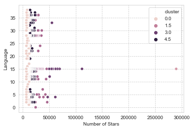

```python
sns.scatterplot(y='Language', x='Number of Stars', hue='cluster', data=df_km)
```

## Scatter Plot 02

- y: Number of Stars
- x: Language
- hue: cluster

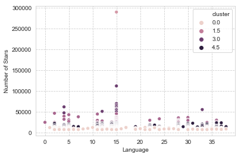

```python
sns.scatterplot(y='Number of Stars', x='Language', hue='cluster', data=df_km)
```

## Scatter Plot 03

- y: cluster
- x: Number of Stars
- hue: cluster

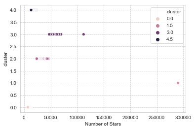

```python
sns.scatterplot(y='cluster', x='Number of Stars', hue='cluster', data=df_km)
```

## Scatter Plot 04

- y: cluster
- x: Language
- hue: cluster

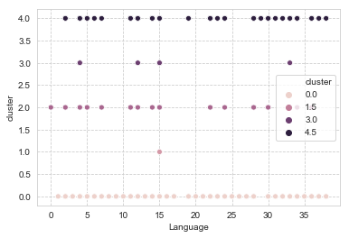

```python
sns.scatterplot(y='cluster', x='Language', hue='cluster', data=df_km)
```

## Scatter Plot 05

- y: Number of Stars
- x: cluster
- hue: cluster

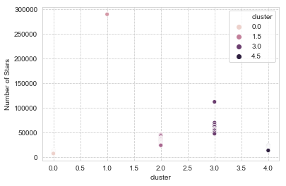

```python
sns.scatterplot(y='Number of Stars', x='cluster', hue='cluster', data=df_km)
```

## Scatter Plot 06

- y: Number of Stars
- x: Language
- hue: cluster

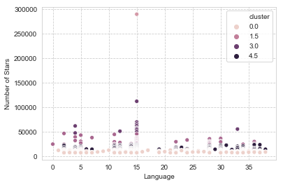

```python
sns.scatterplot(y='Number of Stars', x='Language', hue='cluster', data=df_km)
```

## Scatter Plot 07

- y: Language
- x: cluster
- hue: cluster

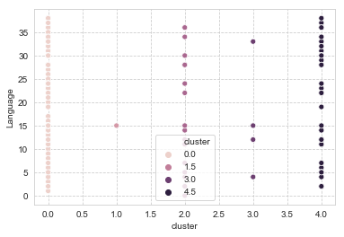

```python
sns.scatterplot(y='Language', x='cluster', hue='cluster', data=df_km)
```

## Scatter Plot 08

- y: cluster
- x: Language
- hue: cluster

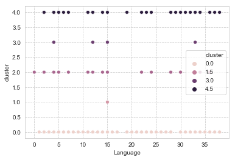

```python
sns.scatterplot(y='cluster', x='Language', hue='cluster', data=df_km)
```